# Introduction to Computer Vision: Plant Seedlings Classification

## Problem Statement

### Context

In recent times, the field of agriculture has been in urgent need of modernizing, since the amount of manual work people need to put in to check if plants are growing correctly is still highly extensive. Despite several advances in agricultural technology, people working in the agricultural industry still need to have the ability to sort and recognize different plants and weeds, which takes a lot of time and effort in the long term. The potential is ripe for this trillion-dollar industry to be greatly impacted by technological innovations that cut down on the requirement for manual labor, and this is where Artificial Intelligence can actually benefit the workers in this field, as **the time and energy required to identify plant seedlings will be greatly shortened by the use of AI and Deep Learning.** The ability to do so far more efficiently and even more effectively than experienced manual labor, could lead to better crop yields, the freeing up of human inolvement for higher-order agricultural decision making, and in the long term will result in more sustainable environmental practices in agriculture as well.

### Objective

The aim of this project is to Build a Convolutional Neural Netowrk to classify plant seedlings into their respective categories.

### Data Dictionary

The Aarhus University Signal Processing group, in collaboration with the University of Southern Denmark, has recently released a dataset containing **images of unique plants belonging to 12 different species.**

- The dataset can be download from Olympus.
- The data file names are:
  - images.npy
  - Labels.csv
- Due to the large volume of data, the images were converted to the images.npy file and the labels are also put into Labels.csv, so that you can work on the data/project seamlessly without having to worry about the high data volume.
- The goal of the project is to create a classifier capable of determining a plant's species from an image.

**List of Species**

- Black-grass
- Charlock
- Cleavers
- Common Chickweed
- Common Wheat
- Fat Hen
- Loose Silky-bent
- Maize
- Scentless Mayweed
- Shepherds Purse
- Small-flowered Cranesbill
- Sugar beet

### **Note: Please use GPU runtime on Google Colab to execute the code faster.**

## Importing necessary libraries

```python
# Installing the libraries with the specified version.

!pip install tensorflow==2.19.0 scikit-learn==1.3.2 seaborn==0.13.1 matplotlib==3.8.0 numpy==1.26.4 pandas==2.2.2 opencv-python==4.8.0.76 -q --user
```

[output not shown]

```python
import os
import numpy as np                                                                               # Importing numpy for Matrix Operations
import pandas as pd                                                                              # Importing pandas to read CSV files
import matplotlib.pyplot as plt                                                                  # Importting matplotlib for Plotting and visualizing images
import math                                                                                      # Importing math module to perform mathematical operations
import cv2                                                                                       # Importing openCV for image processing
import seaborn as sns                                                                            # Importing seaborn to plot graphs
import random                                                                                    # Importing random to generate random numbers

# Tensorflow modules
import tensorflow as tf
from tensorflow.keras.preprocessing.image import ImageDataGenerator
from tensorflow.keras.callbacks import ReduceLROnPlateau                              # Importing the ImageDataGenerator for data augmentation
from tensorflow.keras.models import Sequential                                                   # Importing the sequential module to define a sequential model
from tensorflow.keras.layers import Dense,Dropout,Flatten,Conv2D,MaxPooling2D,BatchNormalization # Defining all the layers to build our CNN Model
from tensorflow.keras.optimizers import Adam,SGD
from tensorflow.keras import backend                                               # Importing the optimizers which can be used in our model
from sklearn import preprocessing                                                                # Importing the preprocessing module to preprocess the data
from sklearn.model_selection import train_test_split                                             # Importing train_test_split function to split the data into train and test
from sklearn.metrics import confusion_matrix                                                     # Importing confusion_matrix to plot the confusion matrix

# Display images using OpenCV
from google.colab.patches import cv2_imshow                                                      # Importing cv2_imshow from google.patches to display images
from sklearn.preprocessing import LabelBinarizer
# Ignore warnings
import warnings
warnings.filterwarnings('ignore')
```

**Note**: *After running the above cell, kindly restart the notebook kernel and run all cells sequentially from the start again.*

## Loading the dataset

```python
# Uncomment and run the below code if you are using google colab
from google.colab import drive
drive.mount('/content/drive')
```

```python
images = np.load('/content/drive/MyDrive/Project Computer Vision Plant seedling classification/images.npy')
labels = pd.read_csv('/content/drive/MyDrive/Project Computer Vision Plant seedling classification/Labels.csv')
```

## Data Overview

### Understand the shape of the dataset

```python
print(images.shape)
print(labels.shape)
```

```
(4750, 128, 128, 3)
(4750, 1)
```

there are 4750 128x128 images in 3 channels

## Exploratory Data Analysis

- EDA is an important part of any project involving data.
- It is important to investigate and understand the data better before building a model with it.
- A few questions have been mentioned below which will help you understand the data better.
- A thorough analysis of the data, in addition to the questions mentioned below, should be done.
1. How are these different category plant images different from each other?
2. Is the dataset provided an imbalance? (Check with using bar plots)

```python
def plot_images(images,labels):
  num_classes=12                                                                  # Number of Classes
  categories=np.unique(labels)
  keys=dict(labels['Label'])                                                      # Obtaing the unique classes from y_train
  rows = 3                                                                        # Defining number of rows=3
  cols = 4                                                                        # Defining number of columns=4
  fig = plt.figure(figsize=(10, 8))                                               # Defining the figure size to 10x8
  for i in range(cols):
      for j in range(rows):
          random_index = np.random.randint(0, len(labels))                        # Generating random indices from the data and plotting the images
          ax = fig.add_subplot(rows, cols, i * rows + j + 1)                      # Adding subplots with 3 rows and 4 columns
          ax.imshow(images[random_index, :])                                      # Plotting the image
          ax.set_title(keys[random_index])
  plt.show()
```

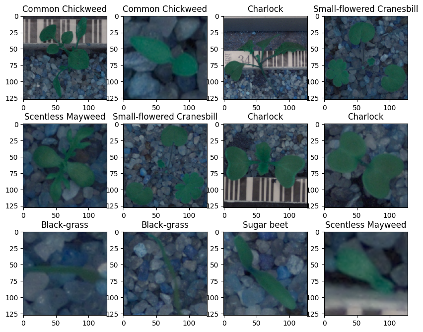

```python
plot_images(images,labels)
```

here are our classes of plants. the imaages are not very high defrinition so teh model can and will only need to learn th eoutline so hopefully a proper;y tuned simple model will be able to accomplish this. The loose beans are going to be an issue though we will definately need a convolution layer size 1x1 to deal with those really skinny ones i bet.

[output not shown]

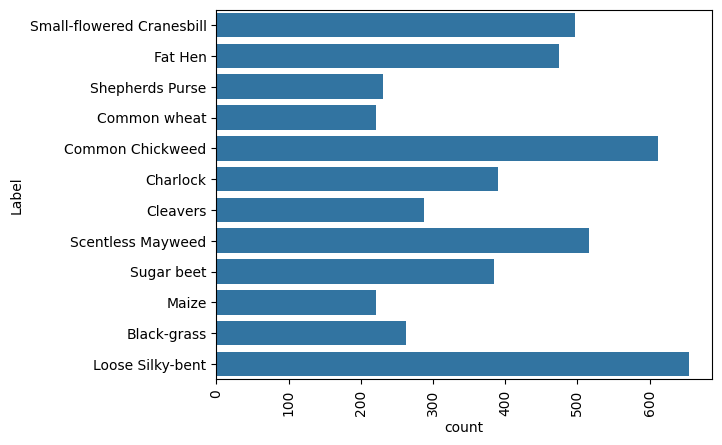

```python
 sns.countplot(labels['Label'])
 plt.xticks(rotation='vertical')
```

its somewhat imbalanced but not terrible

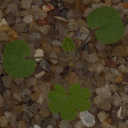

```python
cv2_imshow(images[1])
```

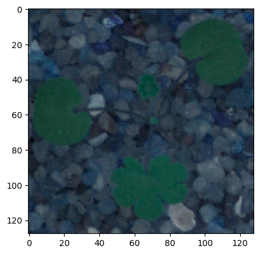

```python
plt.imshow(images[1])
```

The images in the NumPy array are in BGR format because they were likely created using OpenCV. Since other libraries like Matplotlib use RGB, we need to convert the images to RGB for proper visualization.

## Data Pre-Processing

### Convert the BGR images to RGB images.

```python
#loop that iterates over the images and changes them to the rgb
for i in range(len(images)):
  images[i] = cv2.cvtColor(images[i], cv2.COLOR_BGR2RGB)
```

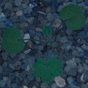

```python
cv2_imshow(images[1])
```

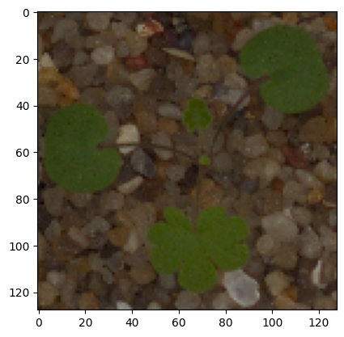

```python
plt.imshow(images[1])
```

### Resize the images

As the size of the images is large, it may be computationally expensive to train on these larger images; therefore, it is preferable to reduce the image size from 128 to 64. Might as well since there are no eyes or noses or anything we basically just need to find outlines and sizes relative to pebbles...

```python
#we will do this with a for loop
images_decreased=[]
height = 64
width = 64
dimensions = (width, height)
for i in range(len(images)):
  images_decreased.append( cv2.resize(images[i], dimensions, interpolation=cv2.INTER_LINEAR))
```

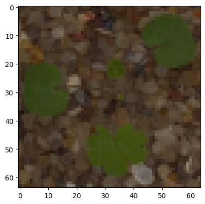

```python
plt.imshow(images_decreased[1])
```

The outline is pretty much unchanged but now there are no folds or creases and such at all

The gb did amazing

### Data Preparation for Modeling

- Before you proceed to build a model, you need to split the data into train, test, and validation to be able to evaluate the model that you build on the train data
- You'll have to encode categorical features and scale the pixel values.
- You will build a model using the train data and then check its performance

**Split the dataset**

```python
X_temp, X_test, y_temp, y_test = train_test_split(np.array(images_decreased),labels , test_size=0.1, random_state=1,stratify=labels)
X_train, X_val, y_train, y_val = train_test_split(X_temp,y_temp , test_size=0.1, random_state=42,stratify=y_temp)
```

```python
print(X_train.shape,y_train.shape)
print(X_val.shape,y_val.shape)
print(X_test.shape,y_test.shape)
```

```
(3847, 64, 64, 3) (3847, 1)
(428, 64, 64, 3) (428, 1)
(475, 64, 64, 3) (475, 1)
```

### Encode the target labels

```python
enc = LabelBinarizer()
y_train_encoded = enc.fit_transform(y_train)
y_val_encoded=enc.transform(y_val)
y_test_encoded=enc.transform(y_test)
```

### Data Normalization

```python
# Normalizing the image pixels for to
X_train_normalized = X_train.astype('float32')/255.0
X_val_normalized = X_val.astype('float32')/255.0
X_test_normalized = X_test.astype('float32')/255.0
```

you can always come back and do LRN normalization later

## Model Building

```python
backend.clear_session()
```

```python
np.random.seed(1)
random.seed(1)
tf.random.set_seed(1)
```

```python
# Intializing a sequential model
model = Sequential()

# Adding a convolution layer with 64 filters each of which is of kernel size 3x3
#relu is the activation function so the model can forget useless info and its easiest to train
#padding same means that the output will be the same size as the original
# Input_shape says what the pixle shape is
model.add(Conv2D(64, (3, 3), activation='relu', padding="same", input_shape=(64, 64, 3)))

# Adding max pooling to reduce the size of output of first conv layer
model.add(MaxPooling2D((2, 2), padding = 'same'))

model.add(Conv2D(32, (3, 3), activation='relu', padding="same"))
model.add(MaxPooling2D((2, 2), padding = 'same'))

# flattening makes it possible to add traditional neural network layers
model.add(Flatten())

# Adding a traditional neural network layer with 24 neurons
model.add(Dense(24, activation='relu'))
model.add(Dropout(0.3))
# Adding the output layer the same size of our number of classes and softmax since this is a multi-class classification problem
model.add(Dense(12, activation='softmax'))

# Using adam because adaptive learnin rates normally do well we can change this later
opt=Adam()
# Compile model
model.compile(optimizer=opt, loss='categorical_crossentropy', metrics=['accuracy'])

# Generating the summary of the model
model.summary()
```

```
Model: "sequential_1"
```

```
┏━━━━━━━━━━━━━━━━━━━━━━━━━━━━━━━━━━━━━━┳━━━━━━━━━━━━━━━━━━━━━━━━━━━━━┳━━━━━━━━━━━━━━━━━┓
┃ Layer (type)                         ┃ Output Shape                ┃         Param # ┃
┡━━━━━━━━━━━━━━━━━━━━━━━━━━━━━━━━━━━━━━╇━━━━━━━━━━━━━━━━━━━━━━━━━━━━━╇━━━━━━━━━━━━━━━━━┩
│ conv2d_5 (Conv2D)                    │ (None, 64, 64, 64)          │           1,792 │
├──────────────────────────────────────┼─────────────────────────────┼─────────────────┤
│ max_pooling2d_5 (MaxPooling2D)       │ (None, 32, 32, 64)          │               0 │
├──────────────────────────────────────┼─────────────────────────────┼─────────────────┤
│ conv2d_6 (Conv2D)                    │ (None, 32, 32, 32)          │          18,464 │
├──────────────────────────────────────┼─────────────────────────────┼─────────────────┤
│ max_pooling2d_6 (MaxPooling2D)       │ (None, 16, 16, 32)          │               0 │
├──────────────────────────────────────┼─────────────────────────────┼─────────────────┤
│ flatten_1 (Flatten)                  │ (None, 8192)                │               0 │
├──────────────────────────────────────┼─────────────────────────────┼─────────────────┤
│ dense_2 (Dense)                      │ (None, 24)                  │         196,632 │
├──────────────────────────────────────┼─────────────────────────────┼─────────────────┤
│ dropout_1 (Dropout)                  │ (None, 24)                  │               0 │
├──────────────────────────────────────┼─────────────────────────────┼─────────────────┤
│ dense_3 (Dense)                      │ (None, 12)                  │             300 │
└──────────────────────────────────────┴─────────────────────────────┴─────────────────┘
```

```
 Total params: 217,188 (848.39 KB)
```

```
 Trainable params: 217,188 (848.39 KB)
```

```
 Non-trainable params: 0 (0.00 B)
```

```python
history_1 = model.fit(
            X_train_normalized, y_train_encoded,
            epochs=30,
            validation_data=(X_val_normalized,y_val_encoded),
            batch_size=32,
            verbose=2
)
```

```
121/121 - 9s - 71ms/step - accuracy: 0.1549 - loss: 2.4147 - val_accuracy: 0.2593 - val_loss: 2.2557
121/121 - 1s - 7ms/step - accuracy: 0.2722 - loss: 2.1465 - val_accuracy: 0.3481 - val_loss: 1.9576
121/121 - 1s - 7ms/step - accuracy: 0.3039 - loss: 1.9534 - val_accuracy: 0.3832 - val_loss: 1.7587
121/121 - 1s - 7ms/step - accuracy: 0.3338 - loss: 1.8293 - val_accuracy: 0.4322 - val_loss: 1.6165
121/121 - 1s - 10ms/step - accuracy: 0.3512 - loss: 1.7585 - val_accuracy: 0.4626 - val_loss: 1.5534
121/121 - 1s - 11ms/step - accuracy: 0.3650 - loss: 1.7154 - val_accuracy: 0.4813 - val_loss: 1.5484
121/121 - 1s - 6ms/step - accuracy: 0.3956 - loss: 1.6482 - val_accuracy: 0.5117 - val_loss: 1.4210
121/121 - 1s - 7ms/step - accuracy: 0.4214 - loss: 1.5906 - val_accuracy: 0.5070 - val_loss: 1.4300
121/121 - 1s - 7ms/step - accuracy: 0.4284 - loss: 1.5438 - val_accuracy: 0.5421 - val_loss: 1.3788
121/121 - 1s - 10ms/step - accuracy: 0.4461 - loss: 1.5090 - val_accuracy: 0.5093 - val_loss: 1.4370
121/121 - 1s - 7ms/step - accuracy: 0.4614 - loss: 1.4624 - val_accuracy: 0.5537 - val_loss: 1.2871
121/121 - 1s - 11ms/step - accuracy: 0.4705 - loss: 1.4454 - val_accuracy: 0.5491 - val_loss: 1.2961
121/121 - 1s - 11ms/step - accuracy: 0.4752 - loss: 1.4317 - val_accuracy: 0.5561 - val_loss: 1.2698
121/121 - 1s - 8ms/step - accuracy: 0.4695 - loss: 1.4125 - val_accuracy: 0.5421 - val_loss: 1.3613
121/121 - 1s - 9ms/step - accuracy: 0.4864 - loss: 1.4068 - val_accuracy: 0.5724 - val_loss: 1.2530
121/121 - 1s - 6ms/step - accuracy: 0.4856 - loss: 1.3984 - val_accuracy: 0.5467 - val_loss: 1.2707
121/121 - 1s - 11ms/step - accuracy: 0.4856 - loss: 1.3930 - val_accuracy: 0.5748 - val_loss: 1.2335
121/121 - 1s - 10ms/step - accuracy: 0.4996 - loss: 1.3656 - val_accuracy: 0.5911 - val_loss: 1.1748
121/121 - 1s - 11ms/step - accuracy: 0.5056 - loss: 1.3398 - val_accuracy: 0.5911 - val_loss: 1.1693
121/121 - 1s - 7ms/step - accuracy: 0.5152 - loss: 1.3127 - val_accuracy: 0.5607 - val_loss: 1.2393
121/121 - 1s - 11ms/step - accuracy: 0.5318 - loss: 1.2670 - val_accuracy: 0.5678 - val_loss: 1.1833
121/121 - 1s - 10ms/step - accuracy: 0.5217 - loss: 1.2904 - val_accuracy: 0.6168 - val_loss: 1.1198
121/121 - 1s - 7ms/step - accuracy: 0.5467 - loss: 1.2423 - val_accuracy: 0.6121 - val_loss: 1.0968
121/121 - 1s - 11ms/step - accuracy: 0.5386 - loss: 1.2517 - val_accuracy: 0.6145 - val_loss: 1.1345
121/121 - 1s - 9ms/step - accuracy: 0.5516 - loss: 1.2249 - val_accuracy: 0.6028 - val_loss: 1.1240
121/121 - 1s - 10ms/step - accuracy: 0.5430 - loss: 1.2579 - val_accuracy: 0.6075 - val_loss: 1.0900
121/121 - 1s - 9ms/step - accuracy: 0.5550 - loss: 1.2067 - val_accuracy: 0.6308 - val_loss: 1.0634
121/121 - 1s - 11ms/step - accuracy: 0.5503 - loss: 1.2216 - val_accuracy: 0.6028 - val_loss: 1.2182
121/121 - 1s - 7ms/step - accuracy: 0.5459 - loss: 1.1927 - val_accuracy: 0.6168 - val_loss: 1.1391
121/121 - 1s - 7ms/step - accuracy: 0.5594 - loss: 1.1800 - val_accuracy: 0.6168 - val_loss: 1.0970
```

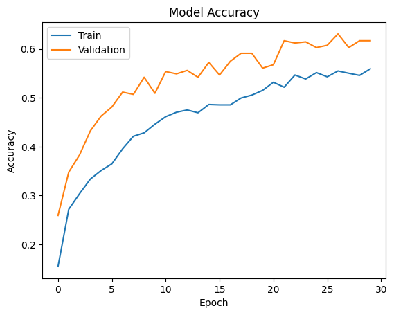

```python
plt.plot(history_1.history['accuracy'])
plt.plot(history_1.history['val_accuracy'])
plt.title('Model Accuracy')
plt.ylabel('Accuracy')
plt.xlabel('Epoch')
plt.legend(['Train', 'Validation'], loc='upper left')
plt.show()
```

needs work

```python
accuracy = model.evaluate(X_test_normalized, y_test_encoded, verbose=2)
```

```
15/15 - 1s - 50ms/step - accuracy: 0.5958 - loss: 1.2384
```

```python
# to get us the output as probablities for each category
y_pred=model.predict(X_test_normalized)
```

```
15/15 ━━━━━━━━━━━━━━━━━━━━ 1s 24ms/step
```

```python
y_pred
```

```
array([[3.05641294e-02, 1.91812233e-05, 2.23950502e-02, ...,
        2.72649893e-04, 1.46146521e-01, 9.42202657e-02],
       [8.54367410e-11, 2.53206193e-01, 3.59456353e-02, ...,
        3.87834273e-02, 6.12279475e-01, 5.85883483e-02],
       [2.29011066e-02, 2.46902778e-06, 2.37416592e-03, ...,
        1.96092785e-03, 5.37378248e-04, 1.50365323e-01],
       ...,
       [5.52824940e-06, 1.18868491e-02, 5.03184676e-01, ...,
        7.36126257e-03, 4.52087522e-02, 1.52433857e-01],
       [5.28991863e-04, 6.55336976e-07, 1.12023245e-05, ...,
        1.42731756e-01, 1.17980186e-02, 1.30358813e-02],
       [3.56159522e-03, 2.77097570e-03, 6.99942932e-02, ...,
        2.38658884e-03, 7.30699860e-04, 3.52595925e-01]], dtype=float32)
```

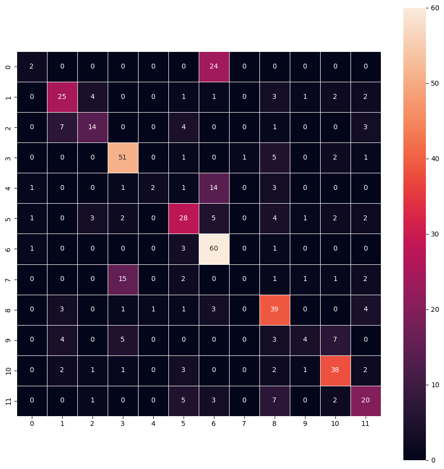

```python
#confusion matrix for model 1 but can be copied for each model:

# Obtaining the categorical values from y_test_encoded and y_pred
y_pred_arg=np.argmax(y_pred,axis=1)
y_test_arg=np.argmax(y_test_encoded,axis=1)

# Plotting the Confusion Matrix using confusion matrix() function which is also predefined tensorflow module
confusion_matrix = tf.math.confusion_matrix(y_test_arg,y_pred_arg)
f, ax = plt.subplots(figsize=(12, 12))
sns.heatmap(
    confusion_matrix,
    annot=True,
    linewidths=.4,
    fmt="d",
    square=True,
    ax=ax
)
plt.show()
```

its not bad for a first try

## Model Performance Improvement

**Reducing the Learning Rate:**

**Hint**: Use **ReduceLRonPlateau()** function that will be used to decrease the learning rate by some factor, if the loss is not decreasing for some time. This may start decreasing the loss at a smaller learning rate. There is a possibility that the loss may still not decrease. This may lead to executing the learning rate reduction again in an attempt to achieve a lower loss.

### **Data Augmentation**

Remember, **data augmentation should not be used in the validation/test data set**.

```python
backend.clear_session()

np.random.seed(1)
random.seed(1)
tf.random.set_seed(1)
```

```python
# Instantiate the ReduceLROnPlateau callback:
reduced_lr = ReduceLROnPlateau(
    monitor='val_loss',  # telling it what to monitor
    factor=0.2,          # Factor by which the learning rate will be reduced
    patience=5,          # Number of epochs with no improvement after which learning rate will be reduced
    min_lr=1e-5,         # Lower bound on the learning rate
    verbose=1            # Print messages about learning rate changes
)
```

```python
history_2 = model.fit(
    X_train_normalized, y_train_encoded,
    epochs=30,
    validation_data=(X_val_normalized, y_val_encoded),
    batch_size=32,
    verbose=2,
    callbacks=[reduced_lr]
)
```

```
121/121 - 2s - 13ms/step - accuracy: 0.5589 - loss: 1.1747 - val_accuracy: 0.6192 - val_loss: 1.0739 - learning_rate: 0.0010
121/121 - 2s - 16ms/step - accuracy: 0.5633 - loss: 1.1600 - val_accuracy: 0.6308 - val_loss: 1.0701 - learning_rate: 0.0010
121/121 - 1s - 8ms/step - accuracy: 0.5734 - loss: 1.1179 - val_accuracy: 0.6332 - val_loss: 1.1092 - learning_rate: 0.0010
121/121 - 1s - 9ms/step - accuracy: 0.5688 - loss: 1.1427 - val_accuracy: 0.6285 - val_loss: 1.1054 - learning_rate: 0.0010
121/121 - 1s - 10ms/step - accuracy: 0.5883 - loss: 1.0997 - val_accuracy: 0.6145 - val_loss: 1.1243 - learning_rate: 0.0010
121/121 - 1s - 8ms/step - accuracy: 0.5794 - loss: 1.0881 - val_accuracy: 0.6192 - val_loss: 1.1027 - learning_rate: 0.0010

Epoch 7: ReduceLROnPlateau reducing learning rate to 0.00020000000949949026.
121/121 - 1s - 10ms/step - accuracy: 0.5992 - loss: 1.0514 - val_accuracy: 0.6402 - val_loss: 1.1255 - learning_rate: 0.0010
121/121 - 1s - 7ms/step - accuracy: 0.5960 - loss: 1.0504 - val_accuracy: 0.6612 - val_loss: 1.0257 - learning_rate: 2.0000e-04
121/121 - 1s - 10ms/step - accuracy: 0.6187 - loss: 1.0091 - val_accuracy: 0.6565 - val_loss: 1.0263 - learning_rate: 2.0000e-04
121/121 - 1s - 10ms/step - accuracy: 0.6275 - loss: 0.9956 - val_accuracy: 0.6612 - val_loss: 1.0275 - learning_rate: 2.0000e-04
121/121 - 1s - 7ms/step - accuracy: 0.6194 - loss: 0.9817 - val_accuracy: 0.6355 - val_loss: 1.0280 - learning_rate: 2.0000e-04
121/121 - 1s - 6ms/step - accuracy: 0.6176 - loss: 0.9935 - val_accuracy: 0.6612 - val_loss: 1.0314 - learning_rate: 2.0000e-04

Epoch 13: ReduceLROnPlateau reducing learning rate to 4.0000001899898055e-05.
121/121 - 1s - 6ms/step - accuracy: 0.6218 - loss: 0.9890 - val_accuracy: 0.6519 - val_loss: 1.0369 - learning_rate: 2.0000e-04
121/121 - 1s - 10ms/step - accuracy: 0.6205 - loss: 0.9737 - val_accuracy: 0.6519 - val_loss: 1.0326 - learning_rate: 4.0000e-05
121/121 - 1s - 12ms/step - accuracy: 0.6236 - loss: 0.9826 - val_accuracy: 0.6565 - val_loss: 1.0292 - learning_rate: 4.0000e-05
121/121 - 1s - 8ms/step - accuracy: 0.6148 - loss: 0.9810 - val_accuracy: 0.6589 - val_loss: 1.0321 - learning_rate: 4.0000e-05
121/121 - 1s - 11ms/step - accuracy: 0.6200 - loss: 0.9834 - val_accuracy: 0.6542 - val_loss: 1.0291 - learning_rate: 4.0000e-05

Epoch 18: ReduceLROnPlateau reducing learning rate to 1e-05.
121/121 - 1s - 9ms/step - accuracy: 0.6132 - loss: 1.0044 - val_accuracy: 0.6542 - val_loss: 1.0349 - learning_rate: 4.0000e-05
121/121 - 1s - 11ms/step - accuracy: 0.6168 - loss: 0.9868 - val_accuracy: 0.6589 - val_loss: 1.0297 - learning_rate: 1.0000e-05
121/121 - 1s - 6ms/step - accuracy: 0.6239 - loss: 1.0049 - val_accuracy: 0.6565 - val_loss: 1.0322 - learning_rate: 1.0000e-05
121/121 - 1s - 7ms/step - accuracy: 0.6267 - loss: 0.9741 - val_accuracy: 0.6565 - val_loss: 1.0302 - learning_rate: 1.0000e-05
121/121 - 1s - 7ms/step - accuracy: 0.6314 - loss: 0.9743 - val_accuracy: 0.6565 - val_loss: 1.0307 - learning_rate: 1.0000e-05
121/121 - 1s - 10ms/step - accuracy: 0.6213 - loss: 0.9789 - val_accuracy: 0.6565 - val_loss: 1.0327 - learning_rate: 1.0000e-05
121/121 - 1s - 7ms/step - accuracy: 0.6330 - loss: 0.9487 - val_accuracy: 0.6589 - val_loss: 1.0319 - learning_rate: 1.0000e-05
121/121 - 1s - 10ms/step - accuracy: 0.6252 - loss: 0.9863 - val_accuracy: 0.6565 - val_loss: 1.0322 - learning_rate: 1.0000e-05
121/121 - 1s - 7ms/step - accuracy: 0.6319 - loss: 0.9546 - val_accuracy: 0.6542 - val_loss: 1.0322 - learning_rate: 1.0000e-05
121/121 - 1s - 10ms/step - accuracy: 0.6220 - loss: 0.9676 - val_accuracy: 0.6612 - val_loss: 1.0312 - learning_rate: 1.0000e-05
121/121 - 1s - 12ms/step - accuracy: 0.6236 - loss: 0.9839 - val_accuracy: 0.6589 - val_loss: 1.0312 - learning_rate: 1.0000e-05
121/121 - 1s - 10ms/step - accuracy: 0.6246 - loss: 0.9766 - val_accuracy: 0.6589 - val_loss: 1.0318 - learning_rate: 1.0000e-05
121/121 - 1s - 9ms/step - accuracy: 0.6166 - loss: 0.9770 - val_accuracy: 0.6589 - val_loss: 1.0313 - learning_rate: 1.0000e-05
```

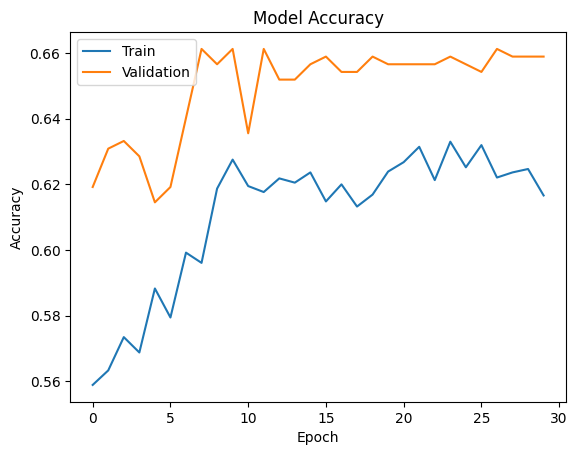

```python
plt.plot(history_2.history['accuracy'])
plt.plot(history_2.history['val_accuracy'])
plt.title('Model Accuracy')
plt.ylabel('Accuracy')
plt.xlabel('Epoch')
plt.legend(['Train', 'Validation'], loc='upper left')
plt.show()
```

```python
y_pred=model.predict(X_test_normalized)
```

```
15/15 ━━━━━━━━━━━━━━━━━━━━ 0s 5ms/step
```

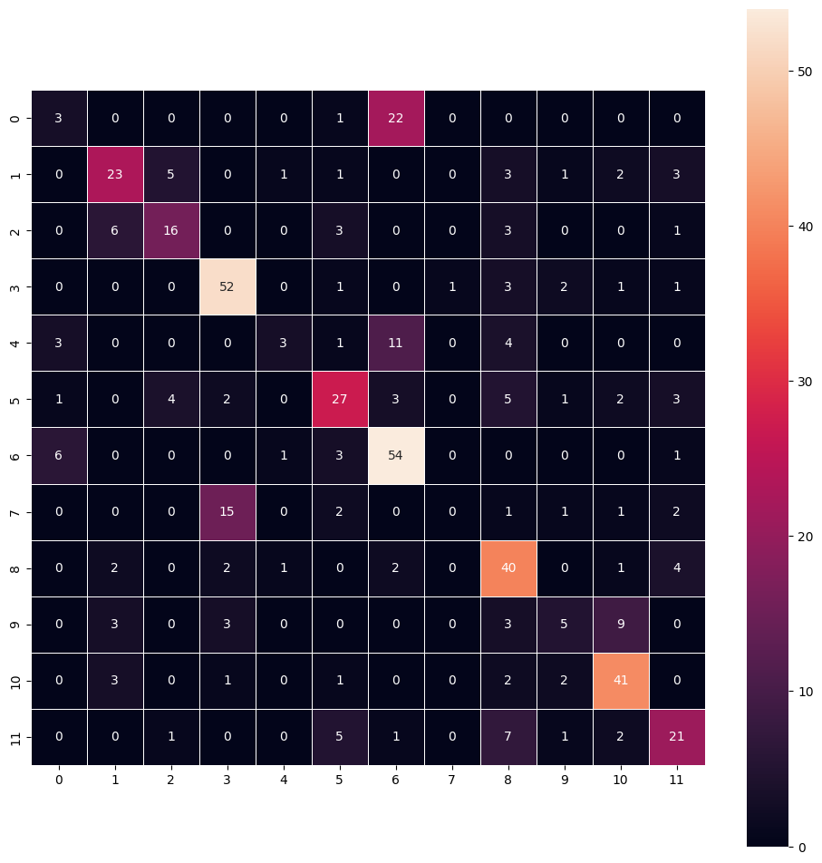

```python
y_pred_arg=np.argmax(y_pred,axis=1)
y_test_arg=np.argmax(y_test_encoded,axis=1)

confusion_matrix = tf.math.confusion_matrix(y_test_arg,y_pred_arg)
f, ax = plt.subplots(figsize=(12, 12))
sns.heatmap(
    confusion_matrix,
    annot=True,
    linewidths=.4,
    fmt="d",
    square=True,
    ax=ax
)
plt.show()
```

a lot of our mistakes are concentrated in a couple classes my suspicion is they are in the string bean/blade of grass type of plant creature so next i want to make a 1x1 convolution layer/filter to try and capture these plants as well as more nueanced edges in other plants.

```python
backend.clear_session()

np.random.seed(1)
random.seed(1)
tf.random.set_seed(1)
```

```python
model_3 = Sequential()

# Adding a 1x1 layer to catch the string beans
model_3.add(Conv2D(32, (1, 1), activation='relu', padding="same", input_shape=(64, 64, 3))) #input shape added here only
model_3.add(MaxPooling2D((2, 2), padding='same'))

model_3.add(Conv2D(64, (3, 3), activation='relu', padding="same"))
model_3.add(MaxPooling2D((2, 2), padding='same'))

model_3.add(Conv2D(32, (3, 3), activation='relu', padding="same"))
model_3.add(MaxPooling2D((2, 2), padding='same'))

model_3.add(Flatten())

model_3.add(Dense(24, activation='relu'))
model_3.add(Dropout(0.3))

model_3.add(Dense(12, activation='softmax'))

opt = Adam()

model_3.compile(optimizer=opt, loss='categorical_crossentropy', metrics=['accuracy'])

model_3.summary()
```

```
Model: "sequential"
```

```
┏━━━━━━━━━━━━━━━━━━━━━━━━━━━━━━━━━━━━━━┳━━━━━━━━━━━━━━━━━━━━━━━━━━━━━┳━━━━━━━━━━━━━━━━━┓
┃ Layer (type)                         ┃ Output Shape                ┃         Param # ┃
┡━━━━━━━━━━━━━━━━━━━━━━━━━━━━━━━━━━━━━━╇━━━━━━━━━━━━━━━━━━━━━━━━━━━━━╇━━━━━━━━━━━━━━━━━┩
│ conv2d (Conv2D)                      │ (None, 64, 64, 32)          │             128 │
├──────────────────────────────────────┼─────────────────────────────┼─────────────────┤
│ max_pooling2d (MaxPooling2D)         │ (None, 32, 32, 32)          │               0 │
├──────────────────────────────────────┼─────────────────────────────┼─────────────────┤
│ conv2d_1 (Conv2D)                    │ (None, 32, 32, 64)          │          18,496 │
├──────────────────────────────────────┼─────────────────────────────┼─────────────────┤
│ max_pooling2d_1 (MaxPooling2D)       │ (None, 16, 16, 64)          │               0 │
├──────────────────────────────────────┼─────────────────────────────┼─────────────────┤
│ conv2d_2 (Conv2D)                    │ (None, 16, 16, 32)          │          18,464 │
├──────────────────────────────────────┼─────────────────────────────┼─────────────────┤
│ max_pooling2d_2 (MaxPooling2D)       │ (None, 8, 8, 32)            │               0 │
├──────────────────────────────────────┼─────────────────────────────┼─────────────────┤
│ flatten (Flatten)                    │ (None, 2048)                │               0 │
├──────────────────────────────────────┼─────────────────────────────┼─────────────────┤
│ dense (Dense)                        │ (None, 24)                  │          49,176 │
├──────────────────────────────────────┼─────────────────────────────┼─────────────────┤
│ dropout (Dropout)                    │ (None, 24)                  │               0 │
├──────────────────────────────────────┼─────────────────────────────┼─────────────────┤
│ dense_1 (Dense)                      │ (None, 12)                  │             300 │
└──────────────────────────────────────┴─────────────────────────────┴─────────────────┘
```

```
 Total params: 86,564 (338.14 KB)
```

```
 Trainable params: 86,564 (338.14 KB)
```

```
 Non-trainable params: 0 (0.00 B)
```

```python
history_3 = model_3.fit(
    X_train_normalized, y_train_encoded,
    epochs=30,
    validation_data=(X_val_normalized, y_val_encoded),
    batch_size=32,
    verbose=2,
    callbacks=[reduced_lr]  # Pass the callback here
)
```

```
121/121 - 9s - 71ms/step - accuracy: 0.1913 - loss: 2.3390 - val_accuracy: 0.3435 - val_loss: 2.0541 - learning_rate: 0.0010
121/121 - 1s - 7ms/step - accuracy: 0.3280 - loss: 1.9725 - val_accuracy: 0.3949 - val_loss: 1.8108 - learning_rate: 0.0010
121/121 - 1s - 7ms/step - accuracy: 0.3702 - loss: 1.8119 - val_accuracy: 0.4650 - val_loss: 1.6183 - learning_rate: 0.0010
121/121 - 1s - 9ms/step - accuracy: 0.4154 - loss: 1.6477 - val_accuracy: 0.5047 - val_loss: 1.4773 - learning_rate: 0.0010
121/121 - 1s - 10ms/step - accuracy: 0.4414 - loss: 1.5551 - val_accuracy: 0.5257 - val_loss: 1.4127 - learning_rate: 0.0010
121/121 - 1s - 5ms/step - accuracy: 0.4788 - loss: 1.4722 - val_accuracy: 0.5631 - val_loss: 1.3414 - learning_rate: 0.0010
121/121 - 1s - 5ms/step - accuracy: 0.4671 - loss: 1.4323 - val_accuracy: 0.5491 - val_loss: 1.3066 - learning_rate: 0.0010
121/121 - 1s - 11ms/step - accuracy: 0.4866 - loss: 1.3839 - val_accuracy: 0.5794 - val_loss: 1.2227 - learning_rate: 0.0010
121/121 - 1s - 10ms/step - accuracy: 0.5079 - loss: 1.3187 - val_accuracy: 0.6215 - val_loss: 1.1764 - learning_rate: 0.0010
121/121 - 1s - 10ms/step - accuracy: 0.5087 - loss: 1.2835 - val_accuracy: 0.6121 - val_loss: 1.1589 - learning_rate: 0.0010
121/121 - 1s - 5ms/step - accuracy: 0.5355 - loss: 1.2516 - val_accuracy: 0.6472 - val_loss: 1.1043 - learning_rate: 0.0010
121/121 - 1s - 6ms/step - accuracy: 0.5534 - loss: 1.2245 - val_accuracy: 0.6682 - val_loss: 1.0460 - learning_rate: 0.0010
121/121 - 1s - 5ms/step - accuracy: 0.5534 - loss: 1.1890 - val_accuracy: 0.6145 - val_loss: 1.1115 - learning_rate: 0.0010
121/121 - 1s - 5ms/step - accuracy: 0.5537 - loss: 1.1779 - val_accuracy: 0.6846 - val_loss: 1.0006 - learning_rate: 0.0010
121/121 - 1s - 12ms/step - accuracy: 0.5638 - loss: 1.1533 - val_accuracy: 0.6519 - val_loss: 1.0443 - learning_rate: 0.0010
121/121 - 1s - 10ms/step - accuracy: 0.5802 - loss: 1.1237 - val_accuracy: 0.6916 - val_loss: 0.9759 - learning_rate: 0.0010
121/121 - 1s - 7ms/step - accuracy: 0.5958 - loss: 1.0985 - val_accuracy: 0.6682 - val_loss: 1.0229 - learning_rate: 0.0010
121/121 - 1s - 6ms/step - accuracy: 0.5851 - loss: 1.1203 - val_accuracy: 0.6893 - val_loss: 0.9534 - learning_rate: 0.0010
121/121 - 1s - 6ms/step - accuracy: 0.5885 - loss: 1.0870 - val_accuracy: 0.6963 - val_loss: 0.9061 - learning_rate: 0.0010
121/121 - 1s - 10ms/step - accuracy: 0.6028 - loss: 1.0530 - val_accuracy: 0.7196 - val_loss: 0.9019 - learning_rate: 0.0010
121/121 - 1s - 5ms/step - accuracy: 0.5934 - loss: 1.0513 - val_accuracy: 0.7243 - val_loss: 0.8595 - learning_rate: 0.0010
121/121 - 1s - 10ms/step - accuracy: 0.6140 - loss: 1.0110 - val_accuracy: 0.7383 - val_loss: 0.8549 - learning_rate: 0.0010
121/121 - 1s - 10ms/step - accuracy: 0.6129 - loss: 1.0308 - val_accuracy: 0.7196 - val_loss: 0.8987 - learning_rate: 0.0010
121/121 - 1s - 5ms/step - accuracy: 0.6135 - loss: 1.0050 - val_accuracy: 0.7266 - val_loss: 0.8550 - learning_rate: 0.0010
121/121 - 1s - 5ms/step - accuracy: 0.6327 - loss: 0.9821 - val_accuracy: 0.7173 - val_loss: 0.8610 - learning_rate: 0.0010
121/121 - 1s - 5ms/step - accuracy: 0.6343 - loss: 0.9536 - val_accuracy: 0.7266 - val_loss: 0.8446 - learning_rate: 0.0010
121/121 - 1s - 5ms/step - accuracy: 0.6343 - loss: 0.9604 - val_accuracy: 0.7383 - val_loss: 0.8190 - learning_rate: 0.0010
121/121 - 1s - 11ms/step - accuracy: 0.6392 - loss: 0.9462 - val_accuracy: 0.7453 - val_loss: 0.8159 - learning_rate: 0.0010
121/121 - 1s - 6ms/step - accuracy: 0.6478 - loss: 0.9392 - val_accuracy: 0.7383 - val_loss: 0.8382 - learning_rate: 0.0010
121/121 - 1s - 7ms/step - accuracy: 0.6434 - loss: 0.9291 - val_accuracy: 0.6986 - val_loss: 0.8959 - learning_rate: 0.0010
```

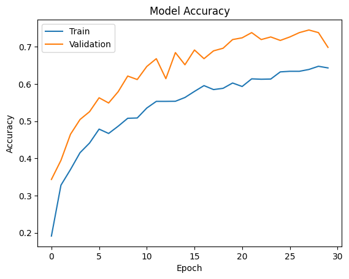

```python
plt.plot(history_3.history['accuracy'])
plt.plot(history_3.history['val_accuracy'])
plt.title('Model Accuracy')
plt.ylabel('Accuracy')
plt.xlabel('Epoch')
plt.legend(['Train', 'Validation'], loc='upper left')
plt.show()
```

this is an improvement but it is not good enough

```python
y_pred=model_3.predict(X_test_normalized)
```

```
15/15 ━━━━━━━━━━━━━━━━━━━━ 1s 71ms/step
```

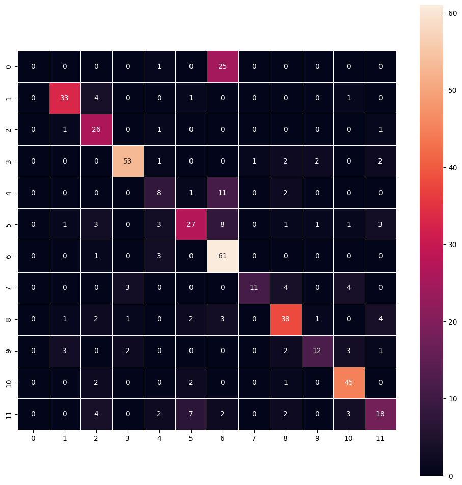

```python
y_pred_arg=np.argmax(y_pred,axis=1)
y_test_arg=np.argmax(y_test_encoded,axis=1)

confusion_matrix = tf.math.confusion_matrix(y_test_arg,y_pred_arg)
f, ax = plt.subplots(figsize=(12, 12))
sns.heatmap(
    confusion_matrix,
    annot=True,
    linewidths=.4,
    fmt="d",
    square=True,
    ax=ax
)
plt.show()
```

it looks like the model found one of the sting beans maybe simply adding another 1x1 will do the trick if not we will try transfer learning or maybe more neurons and or layers after the flattern layers

```python
backend.clear_session()

np.random.seed(1)
random.seed(1)
tf.random.set_seed(1)
```

```python
model_4 = Sequential()

#adding another tiny cnn layer
model_4.add(Conv2D(32, (1, 1), activation='relu', padding="same", input_shape=(64, 64, 3)))
model_4.add(MaxPooling2D((2, 2), padding='same'))

model_4.add(Conv2D(32, (1, 1), activation='relu', padding="same", input_shape=(64, 64, 3)))
model_4.add(MaxPooling2D((2, 2), padding='same'))

model_4.add(Conv2D(64, (3, 3), activation='relu', padding="same"))
model_4.add(MaxPooling2D((2, 2), padding='same'))

model_4.add(Conv2D(32, (3, 3), activation='relu', padding="same"))
model_4.add(MaxPooling2D((2, 2), padding='same'))

model_4.add(Flatten())

model_4.add(Dense(24, activation='relu'))
model_4.add(Dropout(0.3))

model_4.add(Dense(12, activation='softmax'))

opt = Adam()

model_4.compile(optimizer=opt, loss='categorical_crossentropy', metrics=['accuracy'])

model_4.summary()
```

```
Model: "sequential"
```

```
┏━━━━━━━━━━━━━━━━━━━━━━━━━━━━━━━━━━━━━━┳━━━━━━━━━━━━━━━━━━━━━━━━━━━━━┳━━━━━━━━━━━━━━━━━┓
┃ Layer (type)                         ┃ Output Shape                ┃         Param # ┃
┡━━━━━━━━━━━━━━━━━━━━━━━━━━━━━━━━━━━━━━╇━━━━━━━━━━━━━━━━━━━━━━━━━━━━━╇━━━━━━━━━━━━━━━━━┩
│ conv2d (Conv2D)                      │ (None, 64, 64, 32)          │             128 │
├──────────────────────────────────────┼─────────────────────────────┼─────────────────┤
│ max_pooling2d (MaxPooling2D)         │ (None, 32, 32, 32)          │               0 │
├──────────────────────────────────────┼─────────────────────────────┼─────────────────┤
│ conv2d_1 (Conv2D)                    │ (None, 32, 32, 32)          │           1,056 │
├──────────────────────────────────────┼─────────────────────────────┼─────────────────┤
│ max_pooling2d_1 (MaxPooling2D)       │ (None, 16, 16, 32)          │               0 │
├──────────────────────────────────────┼─────────────────────────────┼─────────────────┤
│ conv2d_2 (Conv2D)                    │ (None, 16, 16, 64)          │          18,496 │
├──────────────────────────────────────┼─────────────────────────────┼─────────────────┤
│ max_pooling2d_2 (MaxPooling2D)       │ (None, 8, 8, 64)            │               0 │
├──────────────────────────────────────┼─────────────────────────────┼─────────────────┤
│ conv2d_3 (Conv2D)                    │ (None, 8, 8, 32)            │          18,464 │
├──────────────────────────────────────┼─────────────────────────────┼─────────────────┤
│ max_pooling2d_3 (MaxPooling2D)       │ (None, 4, 4, 32)            │               0 │
├──────────────────────────────────────┼─────────────────────────────┼─────────────────┤
│ flatten (Flatten)                    │ (None, 512)                 │               0 │
├──────────────────────────────────────┼─────────────────────────────┼─────────────────┤
│ dense (Dense)                        │ (None, 24)                  │          12,312 │
├──────────────────────────────────────┼─────────────────────────────┼─────────────────┤
│ dropout (Dropout)                    │ (None, 24)                  │               0 │
├──────────────────────────────────────┼─────────────────────────────┼─────────────────┤
│ dense_1 (Dense)                      │ (None, 12)                  │             300 │
└──────────────────────────────────────┴─────────────────────────────┴─────────────────┘
```

```
 Total params: 50,756 (198.27 KB)
```

```
 Trainable params: 50,756 (198.27 KB)
```

```
 Non-trainable params: 0 (0.00 B)
```

```python
history_4 = model_4.fit(
    X_train_normalized, y_train_encoded,
    epochs=30,
    validation_data=(X_val_normalized, y_val_encoded),
    batch_size=32,
    verbose=2,
    callbacks=[reduced_lr]  # again using reduced lr
)
```

```
121/121 - 8s - 70ms/step - accuracy: 0.1500 - loss: 2.4208 - val_accuracy: 0.2664 - val_loss: 2.3299 - learning_rate: 0.0010
121/121 - 4s - 34ms/step - accuracy: 0.2833 - loss: 2.1687 - val_accuracy: 0.3832 - val_loss: 1.9637 - learning_rate: 0.0010
121/121 - 1s - 10ms/step - accuracy: 0.3556 - loss: 1.9043 - val_accuracy: 0.4276 - val_loss: 1.7721 - learning_rate: 0.0010
121/121 - 1s - 5ms/step - accuracy: 0.3886 - loss: 1.7664 - val_accuracy: 0.4463 - val_loss: 1.6270 - learning_rate: 0.0010
121/121 - 1s - 6ms/step - accuracy: 0.4073 - loss: 1.6722 - val_accuracy: 0.4790 - val_loss: 1.5374 - learning_rate: 0.0010
121/121 - 1s - 10ms/step - accuracy: 0.4411 - loss: 1.5949 - val_accuracy: 0.5093 - val_loss: 1.4296 - learning_rate: 0.0010
121/121 - 1s - 9ms/step - accuracy: 0.4697 - loss: 1.4961 - val_accuracy: 0.5421 - val_loss: 1.3111 - learning_rate: 0.0010
121/121 - 1s - 5ms/step - accuracy: 0.4921 - loss: 1.4083 - val_accuracy: 0.5140 - val_loss: 1.3835 - learning_rate: 0.0010
121/121 - 1s - 5ms/step - accuracy: 0.5290 - loss: 1.3193 - val_accuracy: 0.5584 - val_loss: 1.2323 - learning_rate: 0.0010
121/121 - 1s - 5ms/step - accuracy: 0.5467 - loss: 1.2675 - val_accuracy: 0.5818 - val_loss: 1.1374 - learning_rate: 0.0010
121/121 - 1s - 5ms/step - accuracy: 0.5620 - loss: 1.2080 - val_accuracy: 0.5864 - val_loss: 1.1298 - learning_rate: 0.0010
121/121 - 1s - 5ms/step - accuracy: 0.5867 - loss: 1.1550 - val_accuracy: 0.6121 - val_loss: 1.0875 - learning_rate: 0.0010
121/121 - 1s - 5ms/step - accuracy: 0.5963 - loss: 1.1269 - val_accuracy: 0.6285 - val_loss: 1.0167 - learning_rate: 0.0010
121/121 - 1s - 5ms/step - accuracy: 0.6210 - loss: 1.0610 - val_accuracy: 0.6519 - val_loss: 1.0009 - learning_rate: 0.0010
121/121 - 1s - 5ms/step - accuracy: 0.6239 - loss: 1.0515 - val_accuracy: 0.7079 - val_loss: 0.9269 - learning_rate: 0.0010
121/121 - 1s - 5ms/step - accuracy: 0.6405 - loss: 1.0002 - val_accuracy: 0.6939 - val_loss: 0.9034 - learning_rate: 0.0010
121/121 - 1s - 5ms/step - accuracy: 0.6519 - loss: 0.9715 - val_accuracy: 0.7313 - val_loss: 0.8455 - learning_rate: 0.0010
121/121 - 1s - 5ms/step - accuracy: 0.6740 - loss: 0.9265 - val_accuracy: 0.7290 - val_loss: 0.8561 - learning_rate: 0.0010
121/121 - 1s - 5ms/step - accuracy: 0.6881 - loss: 0.8792 - val_accuracy: 0.7313 - val_loss: 0.8572 - learning_rate: 0.0010
121/121 - 1s - 5ms/step - accuracy: 0.6813 - loss: 0.8937 - val_accuracy: 0.6893 - val_loss: 0.9274 - learning_rate: 0.0010
121/121 - 1s - 5ms/step - accuracy: 0.6998 - loss: 0.8429 - val_accuracy: 0.7150 - val_loss: 0.8666 - learning_rate: 0.0010
121/121 - 1s - 5ms/step - accuracy: 0.6925 - loss: 0.8485 - val_accuracy: 0.7313 - val_loss: 0.8350 - learning_rate: 0.0010
121/121 - 1s - 6ms/step - accuracy: 0.6977 - loss: 0.8280 - val_accuracy: 0.7757 - val_loss: 0.7692 - learning_rate: 0.0010
121/121 - 1s - 6ms/step - accuracy: 0.7115 - loss: 0.7904 - val_accuracy: 0.7313 - val_loss: 0.8305 - learning_rate: 0.0010
121/121 - 1s - 7ms/step - accuracy: 0.7239 - loss: 0.7654 - val_accuracy: 0.7687 - val_loss: 0.7300 - learning_rate: 0.0010
121/121 - 1s - 9ms/step - accuracy: 0.7239 - loss: 0.7605 - val_accuracy: 0.7640 - val_loss: 0.7523 - learning_rate: 0.0010
121/121 - 1s - 5ms/step - accuracy: 0.7265 - loss: 0.7622 - val_accuracy: 0.7757 - val_loss: 0.7123 - learning_rate: 0.0010
121/121 - 1s - 5ms/step - accuracy: 0.7395 - loss: 0.7117 - val_accuracy: 0.7477 - val_loss: 0.7862 - learning_rate: 0.0010
121/121 - 1s - 5ms/step - accuracy: 0.7351 - loss: 0.7298 - val_accuracy: 0.7640 - val_loss: 0.7869 - learning_rate: 0.0010
121/121 - 1s - 5ms/step - accuracy: 0.7481 - loss: 0.6916 - val_accuracy: 0.7874 - val_loss: 0.7060 - learning_rate: 0.0010
```

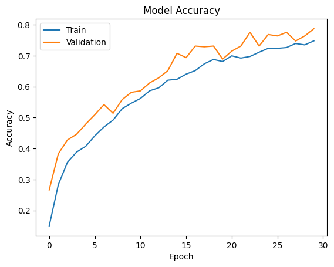

```python
plt.plot(history_4.history['accuracy'])
plt.plot(history_4.history['val_accuracy'])
plt.title('Model Accuracy')
plt.ylabel('Accuracy')
plt.xlabel('Epoch')
plt.legend(['Train', 'Validation'], loc='upper left')
plt.show()
```

with each model we are slowly improving

```python
y_pred=model_4.predict(X_test_normalized)
```

```
15/15 ━━━━━━━━━━━━━━━━━━━━ 1s 43ms/step
```

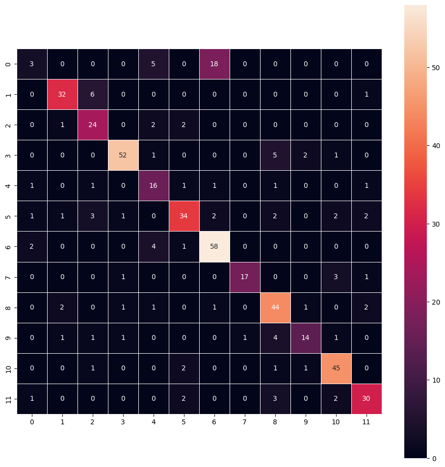

```python
y_pred_arg=np.argmax(y_pred,axis=1)
y_test_arg=np.argmax(y_test_encoded,axis=1)

confusion_matrix = tf.math.confusion_matrix(y_test_arg,y_pred_arg)
f, ax = plt.subplots(figsize=(12, 12))
sns.heatmap(
    confusion_matrix,
    annot=True,
    linewidths=.4,
    fmt="d",
    square=True,
    ax=ax
)
plt.show()
```

```python
backend.clear_session()

np.random.seed(1)
random.seed(1)
tf.random.set_seed(1)
```

```python
model_5 = Sequential()

#adding more tiny cnn layer filters
model_5.add(Conv2D(64, (1, 1), activation='relu', padding="same", input_shape=(64, 64, 3)))
model_5.add(MaxPooling2D((2, 2), padding='same'))

#more filters
model_5.add(Conv2D(64, (1, 1), activation='relu', padding="same", input_shape=(64, 64, 3)))
model_5.add(MaxPooling2D((2, 2), padding='same'))

#more filters
model_5.add(Conv2D(64, (1, 1), activation='relu', padding="same", input_shape=(64, 64, 3)))
model_5.add(MaxPooling2D((2, 2), padding='same'))

model_5.add(Conv2D(64, (3, 3), activation='relu', padding="same"))
model_5.add(MaxPooling2D((2, 2), padding='same'))

model_5.add(Conv2D(32, (3, 3), activation='relu', padding="same"))
model_5.add(MaxPooling2D((2, 2), padding='same'))

model_5.add(Flatten())

model_5.add(Dense(24, activation='relu'))
model_5.add(Dropout(0.3))

model_5.add(Dense(12, activation='softmax'))

opt = Adam()

model_5.compile(optimizer=opt, loss='categorical_crossentropy', metrics=['accuracy'])

model_5.summary()
```

```
Model: "sequential"
```

```
┏━━━━━━━━━━━━━━━━━━━━━━━━━━━━━━━━━━━━━━┳━━━━━━━━━━━━━━━━━━━━━━━━━━━━━┳━━━━━━━━━━━━━━━━━┓
┃ Layer (type)                         ┃ Output Shape                ┃         Param # ┃
┡━━━━━━━━━━━━━━━━━━━━━━━━━━━━━━━━━━━━━━╇━━━━━━━━━━━━━━━━━━━━━━━━━━━━━╇━━━━━━━━━━━━━━━━━┩
│ conv2d (Conv2D)                      │ (None, 64, 64, 64)          │             256 │
├──────────────────────────────────────┼─────────────────────────────┼─────────────────┤
│ max_pooling2d (MaxPooling2D)         │ (None, 32, 32, 64)          │               0 │
├──────────────────────────────────────┼─────────────────────────────┼─────────────────┤
│ conv2d_1 (Conv2D)                    │ (None, 32, 32, 64)          │           4,160 │
├──────────────────────────────────────┼─────────────────────────────┼─────────────────┤
│ max_pooling2d_1 (MaxPooling2D)       │ (None, 16, 16, 64)          │               0 │
├──────────────────────────────────────┼─────────────────────────────┼─────────────────┤
│ conv2d_2 (Conv2D)                    │ (None, 16, 16, 64)          │           4,160 │
├──────────────────────────────────────┼─────────────────────────────┼─────────────────┤
│ max_pooling2d_2 (MaxPooling2D)       │ (None, 8, 8, 64)            │               0 │
├──────────────────────────────────────┼─────────────────────────────┼─────────────────┤
│ conv2d_3 (Conv2D)                    │ (None, 8, 8, 64)            │          36,928 │
├──────────────────────────────────────┼─────────────────────────────┼─────────────────┤
│ max_pooling2d_3 (MaxPooling2D)       │ (None, 4, 4, 64)            │               0 │
├──────────────────────────────────────┼─────────────────────────────┼─────────────────┤
│ conv2d_4 (Conv2D)                    │ (None, 4, 4, 32)            │          18,464 │
├──────────────────────────────────────┼─────────────────────────────┼─────────────────┤
│ max_pooling2d_4 (MaxPooling2D)       │ (None, 2, 2, 32)            │               0 │
├──────────────────────────────────────┼─────────────────────────────┼─────────────────┤
│ flatten (Flatten)                    │ (None, 128)                 │               0 │
├──────────────────────────────────────┼─────────────────────────────┼─────────────────┤
│ dense (Dense)                        │ (None, 24)                  │           3,096 │
├──────────────────────────────────────┼─────────────────────────────┼─────────────────┤
│ dropout (Dropout)                    │ (None, 24)                  │               0 │
├──────────────────────────────────────┼─────────────────────────────┼─────────────────┤
│ dense_1 (Dense)                      │ (None, 12)                  │             300 │
└──────────────────────────────────────┴─────────────────────────────┴─────────────────┘
```

```
 Total params: 67,364 (263.14 KB)
```

```
 Trainable params: 67,364 (263.14 KB)
```

```
 Non-trainable params: 0 (0.00 B)
```

```python
history_5 = model_5.fit(
    X_train_normalized, y_train_encoded,
    epochs=50,
    validation_data=(X_val_normalized, y_val_encoded),
    batch_size=32,
    verbose=2,
    callbacks=[reduced_lr]  # again using reduced lr
)
```

```
121/121 - 11s - 93ms/step - accuracy: 0.1406 - loss: 2.4217 - val_accuracy: 0.2453 - val_loss: 2.2485 - learning_rate: 0.0010
121/121 - 1s - 8ms/step - accuracy: 0.2602 - loss: 2.0749 - val_accuracy: 0.3808 - val_loss: 1.8174 - learning_rate: 0.0010
121/121 - 1s - 10ms/step - accuracy: 0.3678 - loss: 1.7947 - val_accuracy: 0.4509 - val_loss: 1.6359 - learning_rate: 0.0010
121/121 - 1s - 10ms/step - accuracy: 0.4388 - loss: 1.5955 - val_accuracy: 0.5164 - val_loss: 1.4423 - learning_rate: 0.0010
121/121 - 1s - 11ms/step - accuracy: 0.4783 - loss: 1.4917 - val_accuracy: 0.5421 - val_loss: 1.3968 - learning_rate: 0.0010
121/121 - 1s - 11ms/step - accuracy: 0.5069 - loss: 1.4035 - val_accuracy: 0.5701 - val_loss: 1.2579 - learning_rate: 0.0010
121/121 - 1s - 7ms/step - accuracy: 0.5391 - loss: 1.3314 - val_accuracy: 0.6192 - val_loss: 1.1541 - learning_rate: 0.0010
121/121 - 1s - 11ms/step - accuracy: 0.5438 - loss: 1.2922 - val_accuracy: 0.5981 - val_loss: 1.1386 - learning_rate: 0.0010
121/121 - 1s - 7ms/step - accuracy: 0.5669 - loss: 1.2471 - val_accuracy: 0.6449 - val_loss: 1.0443 - learning_rate: 0.0010
121/121 - 1s - 12ms/step - accuracy: 0.5794 - loss: 1.2108 - val_accuracy: 0.6472 - val_loss: 1.0366 - learning_rate: 0.0010
121/121 - 1s - 11ms/step - accuracy: 0.5914 - loss: 1.1764 - val_accuracy: 0.6449 - val_loss: 1.0542 - learning_rate: 0.0010
121/121 - 1s - 9ms/step - accuracy: 0.6007 - loss: 1.1438 - val_accuracy: 0.6379 - val_loss: 1.0256 - learning_rate: 0.0010
121/121 - 1s - 9ms/step - accuracy: 0.6093 - loss: 1.1299 - val_accuracy: 0.6799 - val_loss: 0.9318 - learning_rate: 0.0010
121/121 - 1s - 11ms/step - accuracy: 0.6249 - loss: 1.0652 - val_accuracy: 0.6612 - val_loss: 1.0020 - learning_rate: 0.0010
121/121 - 1s - 7ms/step - accuracy: 0.6384 - loss: 1.0292 - val_accuracy: 0.6682 - val_loss: 0.9323 - learning_rate: 0.0010
121/121 - 1s - 7ms/step - accuracy: 0.6545 - loss: 0.9903 - val_accuracy: 0.6846 - val_loss: 0.9366 - learning_rate: 0.0010
121/121 - 1s - 7ms/step - accuracy: 0.6600 - loss: 0.9815 - val_accuracy: 0.7313 - val_loss: 0.8383 - learning_rate: 0.0010
121/121 - 1s - 7ms/step - accuracy: 0.6579 - loss: 0.9722 - val_accuracy: 0.7033 - val_loss: 0.8883 - learning_rate: 0.0010
121/121 - 1s - 10ms/step - accuracy: 0.6743 - loss: 0.9436 - val_accuracy: 0.7266 - val_loss: 0.8446 - learning_rate: 0.0010
121/121 - 1s - 7ms/step - accuracy: 0.6811 - loss: 0.8959 - val_accuracy: 0.7477 - val_loss: 0.8303 - learning_rate: 0.0010
121/121 - 1s - 8ms/step - accuracy: 0.6883 - loss: 0.8926 - val_accuracy: 0.7477 - val_loss: 0.8307 - learning_rate: 0.0010
121/121 - 1s - 10ms/step - accuracy: 0.6914 - loss: 0.8751 - val_accuracy: 0.7640 - val_loss: 0.7892 - learning_rate: 0.0010
121/121 - 1s - 12ms/step - accuracy: 0.7068 - loss: 0.8305 - val_accuracy: 0.7290 - val_loss: 0.8347 - learning_rate: 0.0010
121/121 - 1s - 9ms/step - accuracy: 0.7195 - loss: 0.8022 - val_accuracy: 0.7734 - val_loss: 0.7718 - learning_rate: 0.0010
121/121 - 1s - 10ms/step - accuracy: 0.7177 - loss: 0.7994 - val_accuracy: 0.7757 - val_loss: 0.7527 - learning_rate: 0.0010
121/121 - 1s - 9ms/step - accuracy: 0.7255 - loss: 0.7893 - val_accuracy: 0.7547 - val_loss: 0.8142 - learning_rate: 0.0010
121/121 - 1s - 7ms/step - accuracy: 0.7302 - loss: 0.7484 - val_accuracy: 0.7500 - val_loss: 0.7671 - learning_rate: 0.0010
121/121 - 1s - 7ms/step - accuracy: 0.7258 - loss: 0.7585 - val_accuracy: 0.7593 - val_loss: 0.7652 - learning_rate: 0.0010
121/121 - 1s - 7ms/step - accuracy: 0.7377 - loss: 0.7185 - val_accuracy: 0.7757 - val_loss: 0.7154 - learning_rate: 0.0010
121/121 - 1s - 10ms/step - accuracy: 0.7382 - loss: 0.7220 - val_accuracy: 0.7407 - val_loss: 0.8585 - learning_rate: 0.0010
121/121 - 1s - 7ms/step - accuracy: 0.7473 - loss: 0.6933 - val_accuracy: 0.7734 - val_loss: 0.7258 - learning_rate: 0.0010
121/121 - 1s - 7ms/step - accuracy: 0.7596 - loss: 0.6828 - val_accuracy: 0.7407 - val_loss: 0.9132 - learning_rate: 0.0010
121/121 - 1s - 7ms/step - accuracy: 0.7544 - loss: 0.6743 - val_accuracy: 0.7593 - val_loss: 0.8136 - learning_rate: 0.0010

Epoch 34: ReduceLROnPlateau reducing learning rate to 0.00020000000949949026.
121/121 - 1s - 10ms/step - accuracy: 0.7627 - loss: 0.6569 - val_accuracy: 0.7407 - val_loss: 0.8735 - learning_rate: 0.0010
```

[output cut: 18 more lines]

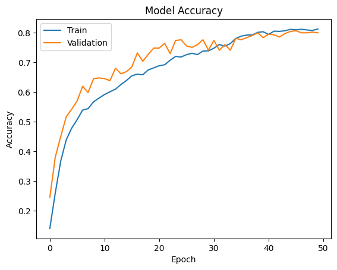

```python
plt.plot(history_5.history['accuracy'])
plt.plot(history_5.history['val_accuracy'])
plt.title('Model Accuracy')
plt.ylabel('Accuracy')
plt.xlabel('Epoch')
plt.legend(['Train', 'Validation'], loc='upper left')
plt.show()
```

it trails off modifications must be made

```python
y_pred=model_5.predict(X_test_normalized)
```

```
15/15 ━━━━━━━━━━━━━━━━━━━━ 1s 50ms/step
```

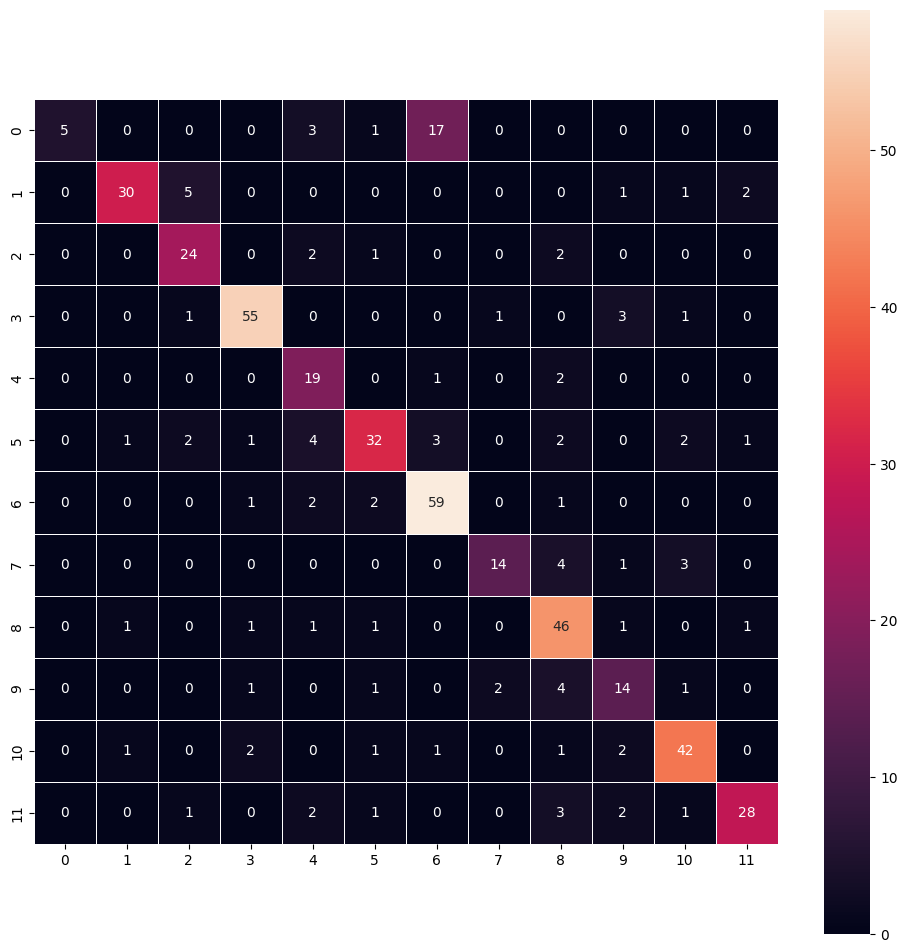

```python
y_pred_arg=np.argmax(y_pred,axis=1)
y_test_arg=np.argmax(y_test_encoded,axis=1)

confusion_matrix = tf.math.confusion_matrix(y_test_arg,y_pred_arg)
f, ax = plt.subplots(figsize=(12, 12))
sns.heatmap(
    confusion_matrix,
    annot=True,
    linewidths=.4,
    fmt="d",
    square=True,
    ax=ax
)
plt.show()
```

we cut down on the remaining class but there are still holdouts it could be string beans but it could also be one of the notorius cranesbills... we may need to modify the strategy... more filters in both the 1x1 and 3x3 will allow the model to learn more diverse patterns. Batch Normalization helps stabilize and speed up the training process. It normalizes the activations of the previous layer, making it easier for the network to learn. It also acts as a regularizer, reducing the risk of overfitting. we added batch normalization for each dense and each convolution layer. we are adding more dense layers and neurons. increasing the droppout to prevent overfitting thanks to added complexity. also reducing the learing rate

```python
backend.clear_session()

np.random.seed(1)
random.seed(1)
tf.random.set_seed(1)
```

```python
model_6 = Sequential()

# Adding more tiny CNN layer filters
model_6.add(Conv2D(64, (1, 1), activation='relu', padding="same", input_shape=(64, 64, 3)))
model_6.add(BatchNormalization()) # Added Batch Normalization
model_6.add(MaxPooling2D((2, 2), padding='same'))

# More filters
model_6.add(Conv2D(128, (1, 1), activation='relu', padding="same")) # Increased filters
model_6.add(BatchNormalization()) # Added Batch Normalization
model_6.add(MaxPooling2D((2, 2), padding='same'))

# More filters
model_6.add(Conv2D(128, (1, 1), activation='relu', padding="same")) # Increased filters
model_6.add(BatchNormalization()) # Added Batch Normalization
model_6.add(MaxPooling2D((2, 2), padding='same'))

# Larger kernel size
model_6.add(Conv2D(128, (3, 3), activation='relu', padding="same")) # Increased filters
model_6.add(BatchNormalization()) # Added Batch Normalization
model_6.add(MaxPooling2D((2, 2), padding='same'))

model_6.add(Conv2D(64, (3, 3), activation='relu', padding="same")) # Increased filters
model_6.add(BatchNormalization()) # Added Batch Normalization
model_6.add(MaxPooling2D((2, 2), padding='same'))

model_6.add(Flatten())

# More neurons
model_6.add(Dense(128, activation='relu')) # Increased neurons
model_6.add(BatchNormalization()) # Added Batch Normalization
model_6.add(Dropout(0.5)) # Increased Dropout

model_6.add(Dense(64, activation='relu')) # Increased neurons, added layer
model_6.add(BatchNormalization()) # Added Batch Normalization
model_6.add(Dropout(0.5)) # Increased Dropout

model_6.add(Dense(12, activation='softmax'))

opt = Adam(learning_rate=0.0005) # Reduced the learning rate slightly

model_6.compile(optimizer=opt, loss='categorical_crossentropy', metrics=['accuracy'])

model_6.summary()
```

```
Model: "sequential_1"
```

```
┏━━━━━━━━━━━━━━━━━━━━━━━━━━━━━━━━━━━━━━┳━━━━━━━━━━━━━━━━━━━━━━━━━━━━━┳━━━━━━━━━━━━━━━━━┓
┃ Layer (type)                         ┃ Output Shape                ┃         Param # ┃
┡━━━━━━━━━━━━━━━━━━━━━━━━━━━━━━━━━━━━━━╇━━━━━━━━━━━━━━━━━━━━━━━━━━━━━╇━━━━━━━━━━━━━━━━━┩
│ conv2d_5 (Conv2D)                    │ (None, 64, 64, 64)          │             256 │
├──────────────────────────────────────┼─────────────────────────────┼─────────────────┤
│ batch_normalization_7                │ (None, 64, 64, 64)          │             256 │
│ (BatchNormalization)                 │                             │                 │
├──────────────────────────────────────┼─────────────────────────────┼─────────────────┤
│ max_pooling2d_5 (MaxPooling2D)       │ (None, 32, 32, 64)          │               0 │
├──────────────────────────────────────┼─────────────────────────────┼─────────────────┤
│ conv2d_6 (Conv2D)                    │ (None, 32, 32, 128)         │           8,320 │
├──────────────────────────────────────┼─────────────────────────────┼─────────────────┤
│ batch_normalization_8                │ (None, 32, 32, 128)         │             512 │
│ (BatchNormalization)                 │                             │                 │
├──────────────────────────────────────┼─────────────────────────────┼─────────────────┤
│ max_pooling2d_6 (MaxPooling2D)       │ (None, 16, 16, 128)         │               0 │
├──────────────────────────────────────┼─────────────────────────────┼─────────────────┤
│ conv2d_7 (Conv2D)                    │ (None, 16, 16, 128)         │          16,512 │
├──────────────────────────────────────┼─────────────────────────────┼─────────────────┤
│ batch_normalization_9                │ (None, 16, 16, 128)         │             512 │
│ (BatchNormalization)                 │                             │                 │
├──────────────────────────────────────┼─────────────────────────────┼─────────────────┤
│ max_pooling2d_7 (MaxPooling2D)       │ (None, 8, 8, 128)           │               0 │
├──────────────────────────────────────┼─────────────────────────────┼─────────────────┤
│ conv2d_8 (Conv2D)                    │ (None, 8, 8, 128)           │         147,584 │
├──────────────────────────────────────┼─────────────────────────────┼─────────────────┤
│ batch_normalization_10               │ (None, 8, 8, 128)           │             512 │
│ (BatchNormalization)                 │                             │                 │
├──────────────────────────────────────┼─────────────────────────────┼─────────────────┤
│ max_pooling2d_8 (MaxPooling2D)       │ (None, 4, 4, 128)           │               0 │
├──────────────────────────────────────┼─────────────────────────────┼─────────────────┤
│ conv2d_9 (Conv2D)                    │ (None, 4, 4, 64)            │          73,792 │
├──────────────────────────────────────┼─────────────────────────────┼─────────────────┤
│ batch_normalization_11               │ (None, 4, 4, 64)            │             256 │
│ (BatchNormalization)                 │                             │                 │
├──────────────────────────────────────┼─────────────────────────────┼─────────────────┤
│ max_pooling2d_9 (MaxPooling2D)       │ (None, 2, 2, 64)            │               0 │
├──────────────────────────────────────┼─────────────────────────────┼─────────────────┤
│ flatten_1 (Flatten)                  │ (None, 256)                 │               0 │
├──────────────────────────────────────┼─────────────────────────────┼─────────────────┤
│ dense_3 (Dense)                      │ (None, 128)                 │          32,896 │
├──────────────────────────────────────┼─────────────────────────────┼─────────────────┤
│ batch_normalization_12               │ (None, 128)                 │             512 │
│ (BatchNormalization)                 │                             │                 │
├──────────────────────────────────────┼─────────────────────────────┼─────────────────┤
│ dropout_2 (Dropout)                  │ (None, 128)                 │               0 │
├──────────────────────────────────────┼─────────────────────────────┼─────────────────┤
│ dense_4 (Dense)                      │ (None, 64)                  │           8,256 │
├──────────────────────────────────────┼─────────────────────────────┼─────────────────┤
│ batch_normalization_13               │ (None, 64)                  │             256 │
│ (BatchNormalization)                 │                             │                 │
├──────────────────────────────────────┼─────────────────────────────┼─────────────────┤
│ dropout_3 (Dropout)                  │ (None, 64)                  │               0 │
├──────────────────────────────────────┼─────────────────────────────┼─────────────────┤
│ dense_5 (Dense)                      │ (None, 12)                  │             780 │
└──────────────────────────────────────┴─────────────────────────────┴─────────────────┘
```

```
 Total params: 291,212 (1.11 MB)
```

```
 Trainable params: 289,804 (1.11 MB)
```

```
 Non-trainable params: 1,408 (5.50 KB)
```

```python
history_6 = model_6.fit(
    X_train_normalized, y_train_encoded,
    epochs=50,
    validation_data=(X_val_normalized, y_val_encoded),
    batch_size=32,
    verbose=2,
    callbacks=[reduced_lr]  # again using reduced lr
)
```

```
121/121 - 22s - 183ms/step - accuracy: 0.2041 - loss: 2.8238 - val_accuracy: 0.1005 - val_loss: 2.9328 - learning_rate: 5.0000e-04
121/121 - 1s - 10ms/step - accuracy: 0.3782 - loss: 1.9743 - val_accuracy: 0.1379 - val_loss: 4.1843 - learning_rate: 5.0000e-04
121/121 - 1s - 11ms/step - accuracy: 0.4760 - loss: 1.5875 - val_accuracy: 0.1402 - val_loss: 5.1159 - learning_rate: 5.0000e-04
121/121 - 1s - 11ms/step - accuracy: 0.5438 - loss: 1.3629 - val_accuracy: 0.1449 - val_loss: 4.8579 - learning_rate: 5.0000e-04
121/121 - 1s - 10ms/step - accuracy: 0.6192 - loss: 1.1642 - val_accuracy: 0.3621 - val_loss: 2.1145 - learning_rate: 5.0000e-04
121/121 - 1s - 10ms/step - accuracy: 0.6561 - loss: 1.0190 - val_accuracy: 0.6238 - val_loss: 1.0518 - learning_rate: 5.0000e-04
121/121 - 1s - 11ms/step - accuracy: 0.7081 - loss: 0.8879 - val_accuracy: 0.7640 - val_loss: 0.6943 - learning_rate: 5.0000e-04
121/121 - 3s - 22ms/step - accuracy: 0.7445 - loss: 0.7901 - val_accuracy: 0.7547 - val_loss: 0.7081 - learning_rate: 5.0000e-04
121/121 - 1s - 12ms/step - accuracy: 0.7775 - loss: 0.6899 - val_accuracy: 0.7874 - val_loss: 0.6474 - learning_rate: 5.0000e-04
121/121 - 2s - 18ms/step - accuracy: 0.7853 - loss: 0.6520 - val_accuracy: 0.7500 - val_loss: 0.6713 - learning_rate: 5.0000e-04
121/121 - 1s - 10ms/step - accuracy: 0.8115 - loss: 0.5759 - val_accuracy: 0.7944 - val_loss: 0.6047 - learning_rate: 5.0000e-04
121/121 - 1s - 10ms/step - accuracy: 0.8295 - loss: 0.5161 - val_accuracy: 0.8458 - val_loss: 0.4269 - learning_rate: 5.0000e-04
121/121 - 1s - 10ms/step - accuracy: 0.8589 - loss: 0.4429 - val_accuracy: 0.8411 - val_loss: 0.4575 - learning_rate: 5.0000e-04
121/121 - 1s - 10ms/step - accuracy: 0.8687 - loss: 0.4077 - val_accuracy: 0.8061 - val_loss: 0.5249 - learning_rate: 5.0000e-04
121/121 - 1s - 10ms/step - accuracy: 0.8820 - loss: 0.3564 - val_accuracy: 0.8458 - val_loss: 0.4417 - learning_rate: 5.0000e-04
121/121 - 1s - 10ms/step - accuracy: 0.8960 - loss: 0.3252 - val_accuracy: 0.8411 - val_loss: 0.4319 - learning_rate: 5.0000e-04

Epoch 17: ReduceLROnPlateau reducing learning rate to 0.00010000000474974513.
121/121 - 1s - 12ms/step - accuracy: 0.8997 - loss: 0.3137 - val_accuracy: 0.8341 - val_loss: 0.5044 - learning_rate: 5.0000e-04
121/121 - 3s - 21ms/step - accuracy: 0.9176 - loss: 0.2562 - val_accuracy: 0.8855 - val_loss: 0.3513 - learning_rate: 1.0000e-04
121/121 - 1s - 10ms/step - accuracy: 0.9306 - loss: 0.2254 - val_accuracy: 0.8995 - val_loss: 0.3224 - learning_rate: 1.0000e-04
121/121 - 1s - 10ms/step - accuracy: 0.9431 - loss: 0.2042 - val_accuracy: 0.8972 - val_loss: 0.3255 - learning_rate: 1.0000e-04
121/121 - 1s - 10ms/step - accuracy: 0.9470 - loss: 0.1843 - val_accuracy: 0.9019 - val_loss: 0.3323 - learning_rate: 1.0000e-04
121/121 - 1s - 11ms/step - accuracy: 0.9579 - loss: 0.1656 - val_accuracy: 0.8995 - val_loss: 0.3277 - learning_rate: 1.0000e-04
121/121 - 1s - 11ms/step - accuracy: 0.9545 - loss: 0.1640 - val_accuracy: 0.9019 - val_loss: 0.3134 - learning_rate: 1.0000e-04
121/121 - 1s - 10ms/step - accuracy: 0.9652 - loss: 0.1560 - val_accuracy: 0.8972 - val_loss: 0.3179 - learning_rate: 1.0000e-04
121/121 - 1s - 9ms/step - accuracy: 0.9620 - loss: 0.1505 - val_accuracy: 0.9019 - val_loss: 0.3217 - learning_rate: 1.0000e-04
121/121 - 1s - 11ms/step - accuracy: 0.9636 - loss: 0.1506 - val_accuracy: 0.8995 - val_loss: 0.3345 - learning_rate: 1.0000e-04
121/121 - 3s - 22ms/step - accuracy: 0.9657 - loss: 0.1375 - val_accuracy: 0.8995 - val_loss: 0.3490 - learning_rate: 1.0000e-04

Epoch 28: ReduceLROnPlateau reducing learning rate to 2.0000000949949027e-05.
121/121 - 2s - 20ms/step - accuracy: 0.9766 - loss: 0.1216 - val_accuracy: 0.9042 - val_loss: 0.3261 - learning_rate: 1.0000e-04
121/121 - 1s - 11ms/step - accuracy: 0.9756 - loss: 0.1182 - val_accuracy: 0.9042 - val_loss: 0.3157 - learning_rate: 2.0000e-05
121/121 - 1s - 10ms/step - accuracy: 0.9826 - loss: 0.1089 - val_accuracy: 0.9042 - val_loss: 0.3058 - learning_rate: 2.0000e-05
121/121 - 1s - 10ms/step - accuracy: 0.9795 - loss: 0.1072 - val_accuracy: 0.9042 - val_loss: 0.3083 - learning_rate: 2.0000e-05
121/121 - 1s - 10ms/step - accuracy: 0.9771 - loss: 0.1094 - val_accuracy: 0.9089 - val_loss: 0.3133 - learning_rate: 2.0000e-05
121/121 - 1s - 10ms/step - accuracy: 0.9766 - loss: 0.1116 - val_accuracy: 0.9042 - val_loss: 0.3184 - learning_rate: 2.0000e-05
```

[output cut: 19 more lines]

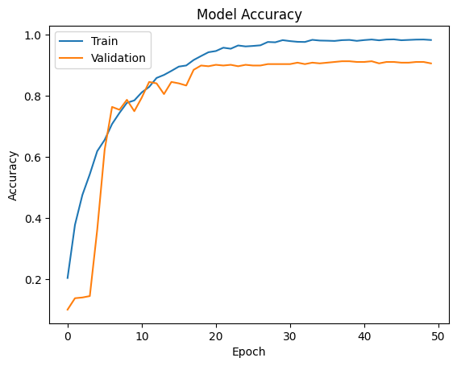

```python
plt.plot(history_6.history['accuracy'])
plt.plot(history_6.history['val_accuracy'])
plt.title('Model Accuracy')
plt.ylabel('Accuracy')
plt.xlabel('Epoch')
plt.legend(['Train', 'Validation'], loc='upper left')
plt.show()
```

```python
y_pred=model_6.predict(X_test_normalized)
```

```
15/15 ━━━━━━━━━━━━━━━━━━━━ 2s 78ms/step
```

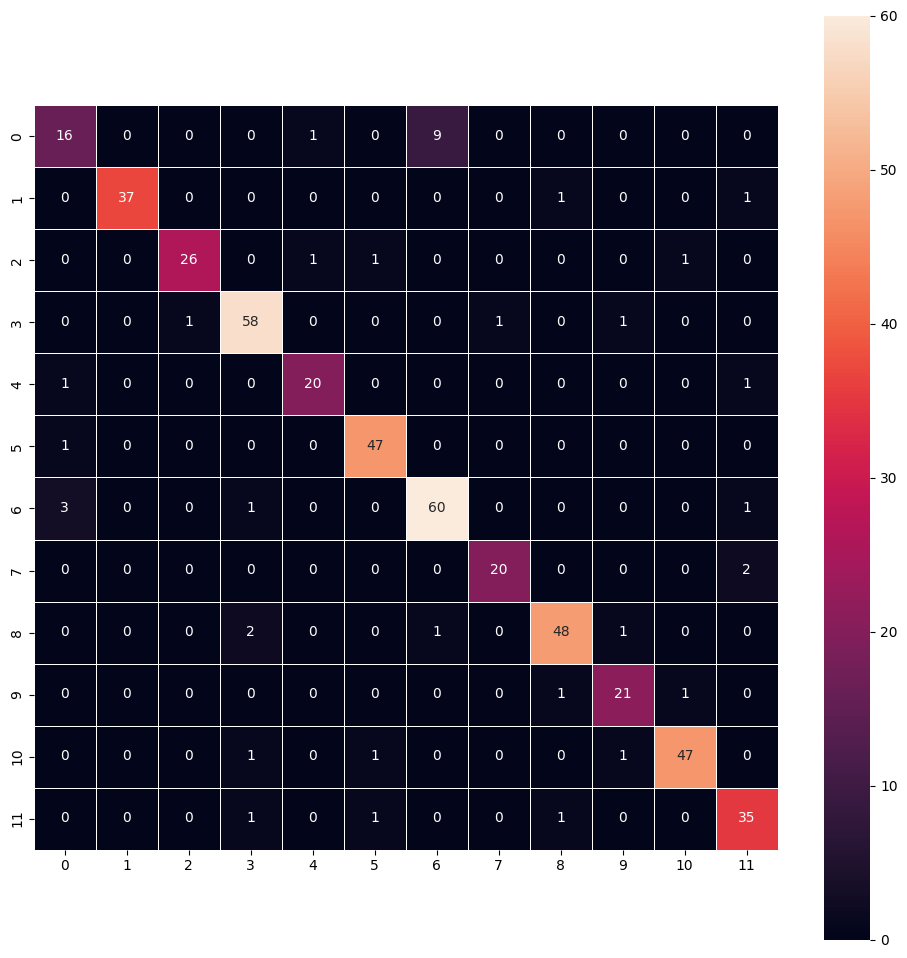

```python
y_pred_arg=np.argmax(y_pred,axis=1)
y_test_arg=np.argmax(y_test_encoded,axis=1)

confusion_matrix = tf.math.confusion_matrix(y_test_arg,y_pred_arg)
f, ax = plt.subplots(figsize=(12, 12))
sns.heatmap(
    confusion_matrix,
    annot=True,
    linewidths=.4,
    fmt="d",
    square=True,
    ax=ax
)
plt.show()
```

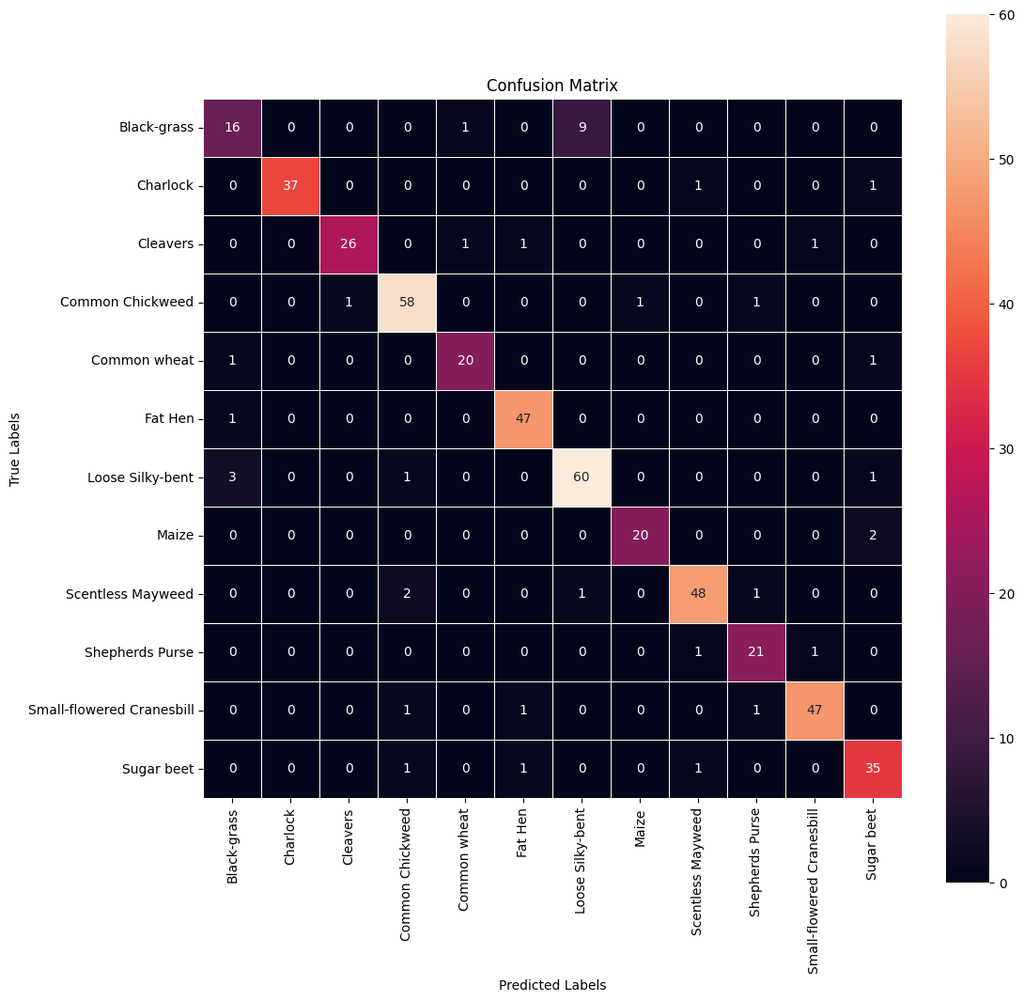

```python
# Obtaining the categorical values from y_test_encoded and y_pred
y_pred_arg=np.argmax(y_pred,axis=1)
y_test_arg=np.argmax(y_test_encoded,axis=1)

# Get the class names from the LabelBinarizer
class_names = enc.classes_

# Create the confusion matrix using TensorFlow
confusion_matrix = tf.math.confusion_matrix(y_test_arg, y_pred_arg)

# Plot the confusion matrix using Seaborn
f, ax = plt.subplots(figsize=(12, 12))
sns.heatmap(
    confusion_matrix,
    annot=True,
    linewidths=.4,
    fmt="d",
    square=True,
    ax=ax,
    xticklabels=class_names,  # Use class names for x-axis labels
    yticklabels=class_names   # Use class names for y-axis labels
)

# Set labels and title
plt.xlabel('Predicted Labels')
plt.ylabel('True Labels')
plt.title('Confusion Matrix')

plt.show()
```

it is indeed the string beans.... ill add more complexity along the same lines i dont think we need transfer learning.

```python
backend.clear_session()

np.random.seed(1)
random.seed(1)
tf.random.set_seed(1)
```

```python
model_7 = Sequential()

# Increased 1x1 layers with more filters and Batch Normalization
model_7.add(Conv2D(128, (1, 1), activation='relu', padding="same", input_shape=(64, 64, 3)))
model_7.add(BatchNormalization())
model_7.add(MaxPooling2D((2, 2), padding='same'))

model_7.add(Conv2D(128, (1, 1), activation='relu', padding="same"))
model_7.add(BatchNormalization())
model_7.add(MaxPooling2D((2, 2), padding='same'))

model_7.add(Conv2D(128, (1, 1), activation='relu', padding="same"))
model_7.add(BatchNormalization())
model_7.add(MaxPooling2D((2, 2), padding='same'))

# Standard 3x3 Conv2D layers with more filters and Batch Normalization
model_7.add(Conv2D(256, (3, 3), activation='relu', padding="same"))
model_7.add(BatchNormalization())
model_7.add(MaxPooling2D((2, 2), padding='same'))

model_7.add(Conv2D(256, (3, 3), activation='relu', padding="same"))
model_7.add(BatchNormalization())
model_7.add(MaxPooling2D((2, 2), padding='same'))

# Flatten and Dense layers
model_7.add(Flatten())

# Increased number of neurons and dropout in Dense layers
model_7.add(Dense(512, activation='relu'))
model_7.add(BatchNormalization())
model_7.add(Dropout(0.6))  # Increased dropout

model_7.add(Dense(256, activation='relu'))
model_7.add(BatchNormalization())
model_7.add(Dropout(0.6))

model_7.add(Dense(12, activation='softmax'))

# Using a reduced learning rate
opt = Adam(learning_rate=0.0001)  # Reduced learning rate

model_7.compile(optimizer=opt, loss='categorical_crossentropy', metrics=['accuracy'])

model_7.summary()
```

```
Model: "sequential"
```

```
┏━━━━━━━━━━━━━━━━━━━━━━━━━━━━━━━━━━━━━━┳━━━━━━━━━━━━━━━━━━━━━━━━━━━━━┳━━━━━━━━━━━━━━━━━┓
┃ Layer (type)                         ┃ Output Shape                ┃         Param # ┃
┡━━━━━━━━━━━━━━━━━━━━━━━━━━━━━━━━━━━━━━╇━━━━━━━━━━━━━━━━━━━━━━━━━━━━━╇━━━━━━━━━━━━━━━━━┩
│ conv2d (Conv2D)                      │ (None, 64, 64, 128)         │             512 │
├──────────────────────────────────────┼─────────────────────────────┼─────────────────┤
│ batch_normalization                  │ (None, 64, 64, 128)         │             512 │
│ (BatchNormalization)                 │                             │                 │
├──────────────────────────────────────┼─────────────────────────────┼─────────────────┤
│ max_pooling2d (MaxPooling2D)         │ (None, 32, 32, 128)         │               0 │
├──────────────────────────────────────┼─────────────────────────────┼─────────────────┤
│ conv2d_1 (Conv2D)                    │ (None, 32, 32, 128)         │          16,512 │
├──────────────────────────────────────┼─────────────────────────────┼─────────────────┤
│ batch_normalization_1                │ (None, 32, 32, 128)         │             512 │
│ (BatchNormalization)                 │                             │                 │
├──────────────────────────────────────┼─────────────────────────────┼─────────────────┤
│ max_pooling2d_1 (MaxPooling2D)       │ (None, 16, 16, 128)         │               0 │
├──────────────────────────────────────┼─────────────────────────────┼─────────────────┤
│ conv2d_2 (Conv2D)                    │ (None, 16, 16, 128)         │          16,512 │
├──────────────────────────────────────┼─────────────────────────────┼─────────────────┤
│ batch_normalization_2                │ (None, 16, 16, 128)         │             512 │
│ (BatchNormalization)                 │                             │                 │
├──────────────────────────────────────┼─────────────────────────────┼─────────────────┤
│ max_pooling2d_2 (MaxPooling2D)       │ (None, 8, 8, 128)           │               0 │
├──────────────────────────────────────┼─────────────────────────────┼─────────────────┤
│ conv2d_3 (Conv2D)                    │ (None, 8, 8, 256)           │         295,168 │
├──────────────────────────────────────┼─────────────────────────────┼─────────────────┤
│ batch_normalization_3                │ (None, 8, 8, 256)           │           1,024 │
│ (BatchNormalization)                 │                             │                 │
├──────────────────────────────────────┼─────────────────────────────┼─────────────────┤
│ max_pooling2d_3 (MaxPooling2D)       │ (None, 4, 4, 256)           │               0 │
├──────────────────────────────────────┼─────────────────────────────┼─────────────────┤
│ conv2d_4 (Conv2D)                    │ (None, 4, 4, 256)           │         590,080 │
├──────────────────────────────────────┼─────────────────────────────┼─────────────────┤
│ batch_normalization_4                │ (None, 4, 4, 256)           │           1,024 │
│ (BatchNormalization)                 │                             │                 │
├──────────────────────────────────────┼─────────────────────────────┼─────────────────┤
│ max_pooling2d_4 (MaxPooling2D)       │ (None, 2, 2, 256)           │               0 │
├──────────────────────────────────────┼─────────────────────────────┼─────────────────┤
│ flatten (Flatten)                    │ (None, 1024)                │               0 │
├──────────────────────────────────────┼─────────────────────────────┼─────────────────┤
│ dense (Dense)                        │ (None, 512)                 │         524,800 │
├──────────────────────────────────────┼─────────────────────────────┼─────────────────┤
│ batch_normalization_5                │ (None, 512)                 │           2,048 │
│ (BatchNormalization)                 │                             │                 │
├──────────────────────────────────────┼─────────────────────────────┼─────────────────┤
│ dropout (Dropout)                    │ (None, 512)                 │               0 │
├──────────────────────────────────────┼─────────────────────────────┼─────────────────┤
│ dense_1 (Dense)                      │ (None, 256)                 │         131,328 │
├──────────────────────────────────────┼─────────────────────────────┼─────────────────┤
│ batch_normalization_6                │ (None, 256)                 │           1,024 │
│ (BatchNormalization)                 │                             │                 │
├──────────────────────────────────────┼─────────────────────────────┼─────────────────┤
│ dropout_1 (Dropout)                  │ (None, 256)                 │               0 │
├──────────────────────────────────────┼─────────────────────────────┼─────────────────┤
│ dense_2 (Dense)                      │ (None, 12)                  │           3,084 │
└──────────────────────────────────────┴─────────────────────────────┴─────────────────┘
```

```
 Total params: 1,584,652 (6.04 MB)
```

```
 Trainable params: 1,581,324 (6.03 MB)
```

```
 Non-trainable params: 3,328 (13.00 KB)
```

```python
history_7 = model_7.fit(
    X_train_normalized, y_train_encoded,
    epochs=75,  # Increased epochs
    validation_data=(X_val_normalized, y_val_encoded),
    batch_size=32,
    verbose=2,
    callbacks=[reduced_lr]
)
```

```
121/121 - 21s - 177ms/step - accuracy: 0.1999 - loss: 3.2446 - val_accuracy: 0.1005 - val_loss: 2.8087 - learning_rate: 1.0000e-04
121/121 - 6s - 47ms/step - accuracy: 0.3397 - loss: 2.4438 - val_accuracy: 0.1379 - val_loss: 3.6432 - learning_rate: 1.0000e-04
121/121 - 2s - 20ms/step - accuracy: 0.4315 - loss: 1.9681 - val_accuracy: 0.1822 - val_loss: 4.1127 - learning_rate: 1.0000e-04
121/121 - 2s - 14ms/step - accuracy: 0.4708 - loss: 1.7611 - val_accuracy: 0.1729 - val_loss: 3.8395 - learning_rate: 1.0000e-04
121/121 - 3s - 23ms/step - accuracy: 0.5209 - loss: 1.5651 - val_accuracy: 0.3154 - val_loss: 2.1693 - learning_rate: 1.0000e-04
121/121 - 2s - 15ms/step - accuracy: 0.5838 - loss: 1.3706 - val_accuracy: 0.5771 - val_loss: 1.1465 - learning_rate: 1.0000e-04
121/121 - 2s - 14ms/step - accuracy: 0.6114 - loss: 1.2026 - val_accuracy: 0.7664 - val_loss: 0.7649 - learning_rate: 1.0000e-04
121/121 - 3s - 22ms/step - accuracy: 0.6501 - loss: 1.0634 - val_accuracy: 0.8037 - val_loss: 0.6635 - learning_rate: 1.0000e-04
121/121 - 2s - 21ms/step - accuracy: 0.6811 - loss: 0.9524 - val_accuracy: 0.8107 - val_loss: 0.6218 - learning_rate: 1.0000e-04
121/121 - 3s - 22ms/step - accuracy: 0.7117 - loss: 0.8785 - val_accuracy: 0.8388 - val_loss: 0.5675 - learning_rate: 1.0000e-04
121/121 - 2s - 16ms/step - accuracy: 0.7481 - loss: 0.7610 - val_accuracy: 0.8154 - val_loss: 0.5619 - learning_rate: 1.0000e-04
121/121 - 2s - 16ms/step - accuracy: 0.7655 - loss: 0.6920 - val_accuracy: 0.8318 - val_loss: 0.5459 - learning_rate: 1.0000e-04
121/121 - 2s - 20ms/step - accuracy: 0.8030 - loss: 0.6209 - val_accuracy: 0.8481 - val_loss: 0.5070 - learning_rate: 1.0000e-04
121/121 - 3s - 21ms/step - accuracy: 0.8128 - loss: 0.5669 - val_accuracy: 0.8388 - val_loss: 0.5027 - learning_rate: 1.0000e-04
121/121 - 2s - 15ms/step - accuracy: 0.8253 - loss: 0.4930 - val_accuracy: 0.8621 - val_loss: 0.4396 - learning_rate: 1.0000e-04
121/121 - 3s - 21ms/step - accuracy: 0.8516 - loss: 0.4395 - val_accuracy: 0.8294 - val_loss: 0.5018 - learning_rate: 1.0000e-04
121/121 - 2s - 16ms/step - accuracy: 0.8573 - loss: 0.4040 - val_accuracy: 0.8575 - val_loss: 0.5104 - learning_rate: 1.0000e-04
121/121 - 2s - 15ms/step - accuracy: 0.8711 - loss: 0.3688 - val_accuracy: 0.8621 - val_loss: 0.4401 - learning_rate: 1.0000e-04
121/121 - 2s - 20ms/step - accuracy: 0.8802 - loss: 0.3529 - val_accuracy: 0.8645 - val_loss: 0.4811 - learning_rate: 1.0000e-04

Epoch 20: ReduceLROnPlateau reducing learning rate to 1.9999999494757503e-05.
121/121 - 2s - 14ms/step - accuracy: 0.8887 - loss: 0.3045 - val_accuracy: 0.8598 - val_loss: 0.4473 - learning_rate: 1.0000e-04
121/121 - 2s - 15ms/step - accuracy: 0.9093 - loss: 0.2603 - val_accuracy: 0.8832 - val_loss: 0.4044 - learning_rate: 2.0000e-05
121/121 - 2s - 14ms/step - accuracy: 0.9155 - loss: 0.2489 - val_accuracy: 0.8785 - val_loss: 0.4214 - learning_rate: 2.0000e-05
121/121 - 3s - 22ms/step - accuracy: 0.9132 - loss: 0.2441 - val_accuracy: 0.8808 - val_loss: 0.4036 - learning_rate: 2.0000e-05
121/121 - 2s - 20ms/step - accuracy: 0.9277 - loss: 0.2180 - val_accuracy: 0.8832 - val_loss: 0.4099 - learning_rate: 2.0000e-05
121/121 - 2s - 21ms/step - accuracy: 0.9319 - loss: 0.2011 - val_accuracy: 0.8879 - val_loss: 0.4097 - learning_rate: 2.0000e-05
121/121 - 2s - 14ms/step - accuracy: 0.9345 - loss: 0.2013 - val_accuracy: 0.8808 - val_loss: 0.4129 - learning_rate: 2.0000e-05
121/121 - 3s - 21ms/step - accuracy: 0.9348 - loss: 0.1894 - val_accuracy: 0.8879 - val_loss: 0.4018 - learning_rate: 2.0000e-05
121/121 - 3s - 21ms/step - accuracy: 0.9415 - loss: 0.1767 - val_accuracy: 0.8832 - val_loss: 0.3969 - learning_rate: 2.0000e-05
121/121 - 3s - 22ms/step - accuracy: 0.9465 - loss: 0.1609 - val_accuracy: 0.8832 - val_loss: 0.4003 - learning_rate: 2.0000e-05
121/121 - 2s - 14ms/step - accuracy: 0.9522 - loss: 0.1491 - val_accuracy: 0.8855 - val_loss: 0.4015 - learning_rate: 2.0000e-05
121/121 - 3s - 21ms/step - accuracy: 0.9465 - loss: 0.1598 - val_accuracy: 0.8855 - val_loss: 0.4075 - learning_rate: 2.0000e-05
121/121 - 2s - 14ms/step - accuracy: 0.9532 - loss: 0.1444 - val_accuracy: 0.8855 - val_loss: 0.4102 - learning_rate: 2.0000e-05

Epoch 33: ReduceLROnPlateau reducing learning rate to 1e-05.
121/121 - 2s - 15ms/step - accuracy: 0.9589 - loss: 0.1362 - val_accuracy: 0.8832 - val_loss: 0.3969 - learning_rate: 2.0000e-05
121/121 - 3s - 21ms/step - accuracy: 0.9550 - loss: 0.1419 - val_accuracy: 0.8808 - val_loss: 0.4014 - learning_rate: 1.0000e-05
121/121 - 2s - 16ms/step - accuracy: 0.9574 - loss: 0.1373 - val_accuracy: 0.8762 - val_loss: 0.4020 - learning_rate: 1.0000e-05
121/121 - 2s - 14ms/step - accuracy: 0.9618 - loss: 0.1259 - val_accuracy: 0.8808 - val_loss: 0.3986 - learning_rate: 1.0000e-05
```

[output cut: 24 more lines]

```
121/121 - 2s - 14ms/step - accuracy: 0.9875 - loss: 0.0610 - val_accuracy: 0.8879 - val_loss: 0.4098 - learning_rate: 1.0000e-05
121/121 - 3s - 21ms/step - accuracy: 0.9860 - loss: 0.0601 - val_accuracy: 0.8808 - val_loss: 0.4206 - learning_rate: 1.0000e-05
121/121 - 3s - 21ms/step - accuracy: 0.9831 - loss: 0.0652 - val_accuracy: 0.8925 - val_loss: 0.4115 - learning_rate: 1.0000e-05
121/121 - 3s - 22ms/step - accuracy: 0.9847 - loss: 0.0593 - val_accuracy: 0.8855 - val_loss: 0.4097 - learning_rate: 1.0000e-05
121/121 - 3s - 21ms/step - accuracy: 0.9870 - loss: 0.0597 - val_accuracy: 0.8925 - val_loss: 0.4089 - learning_rate: 1.0000e-05
121/121 - 2s - 15ms/step - accuracy: 0.9867 - loss: 0.0613 - val_accuracy: 0.8855 - val_loss: 0.4221 - learning_rate: 1.0000e-05
121/121 - 2s - 15ms/step - accuracy: 0.9875 - loss: 0.0547 - val_accuracy: 0.8832 - val_loss: 0.4194 - learning_rate: 1.0000e-05
121/121 - 2s - 14ms/step - accuracy: 0.9860 - loss: 0.0541 - val_accuracy: 0.8902 - val_loss: 0.4036 - learning_rate: 1.0000e-05
121/121 - 3s - 21ms/step - accuracy: 0.9880 - loss: 0.0556 - val_accuracy: 0.8879 - val_loss: 0.4098 - learning_rate: 1.0000e-05
121/121 - 2s - 14ms/step - accuracy: 0.9867 - loss: 0.0551 - val_accuracy: 0.8949 - val_loss: 0.4143 - learning_rate: 1.0000e-05
121/121 - 2s - 16ms/step - accuracy: 0.9896 - loss: 0.0506 - val_accuracy: 0.8972 - val_loss: 0.4034 - learning_rate: 1.0000e-05
121/121 - 2s - 15ms/step - accuracy: 0.9914 - loss: 0.0460 - val_accuracy: 0.8925 - val_loss: 0.4039 - learning_rate: 1.0000e-05
121/121 - 2s - 15ms/step - accuracy: 0.9904 - loss: 0.0463 - val_accuracy: 0.8925 - val_loss: 0.4103 - learning_rate: 1.0000e-05
121/121 - 2s - 14ms/step - accuracy: 0.9901 - loss: 0.0488 - val_accuracy: 0.8972 - val_loss: 0.4162 - learning_rate: 1.0000e-05
121/121 - 2s - 14ms/step - accuracy: 0.9919 - loss: 0.0470 - val_accuracy: 0.9042 - val_loss: 0.4131 - learning_rate: 1.0000e-05
```

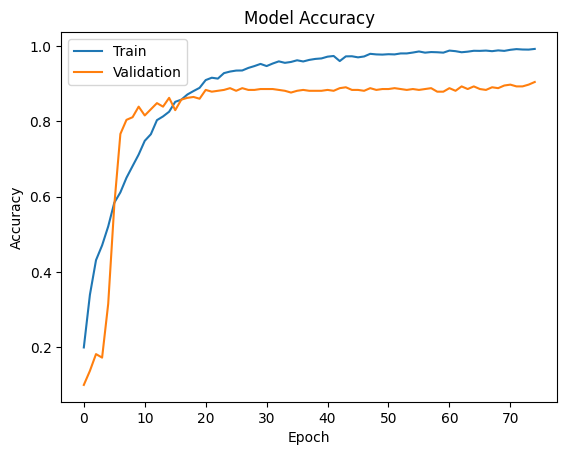

```python
plt.plot(history_7.history['accuracy'])
plt.plot(history_7.history['val_accuracy'])
plt.title('Model Accuracy')
plt.ylabel('Accuracy')
plt.xlabel('Epoch')
plt.legend(['Train', 'Validation'], loc='upper left')
plt.show()
```

```python
y_pred=model_7.predict(X_test_normalized)
```

```
15/15 ━━━━━━━━━━━━━━━━━━━━ 2s 83ms/step
```

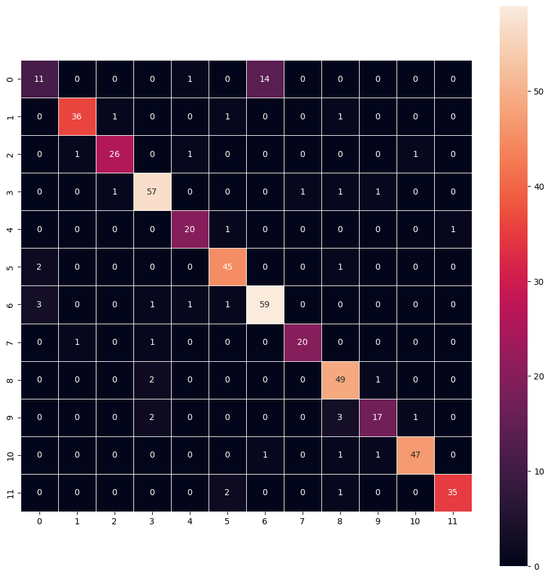

```python
y_pred_arg=np.argmax(y_pred,axis=1)
y_test_arg=np.argmax(y_test_encoded,axis=1)

confusion_matrix = tf.math.confusion_matrix(y_test_arg,y_pred_arg)
f, ax = plt.subplots(figsize=(12, 12))
sns.heatmap(
    confusion_matrix,
    annot=True,
    linewidths=.4,
    fmt="d",
    square=True,
    ax=ax
)
plt.show()
```

this model did no better... the low pixel images dont need complexity. looks like overfitting. next we will try data augmentation because we need to figure out the misclassification in our remaining class rather than relying on transfer model. model 6 did as good as 7 but is simpler so we can forget we tried model 7. we may need to play around with patience and factor values

```python
#run this to define the datagen then you can modify it later

datagen = ImageDataGenerator(
    rotation_range=20,
    width_shift_range=0.2,
    height_shift_range=0.2,
    shear_range=0.2,
    zoom_range=0.2,
    horizontal_flip=True,
    fill_mode='nearest'
)
```

```python
datagen.fit(X_train_normalized)
```

```python
backend.clear_session()

np.random.seed(1)
random.seed(1)
tf.random.set_seed(1)
```

```python
#copy and paste of model 6
model_8 = Sequential()

# Adding more tiny CNN layer filters
model_8.add(Conv2D(64, (1, 1), activation='relu', padding="same", input_shape=(64, 64, 3)))
model_8.add(BatchNormalization())  # Added Batch Normalization
model_8.add(MaxPooling2D((2, 2), padding='same'))

# More filters
model_8.add(Conv2D(128, (1, 1), activation='relu', padding="same"))  # Increased filters
model_8.add(BatchNormalization())  # Added Batch Normalization
model_8.add(MaxPooling2D((2, 2), padding='same'))

# More filters
model_8.add(Conv2D(128, (1, 1), activation='relu', padding="same"))  # Increased filters
model_8.add(BatchNormalization())  # Added Batch Normalization
model_8.add(MaxPooling2D((2, 2), padding='same'))

# Larger kernel size
model_8.add(Conv2D(128, (3, 3), activation='relu', padding="same"))  # Increased filters
model_8.add(BatchNormalization())  # Added Batch Normalization
model_8.add(MaxPooling2D((2, 2), padding='same'))

model_8.add(Conv2D(64, (3, 3), activation='relu', padding="same"))  # Increased filters
model_8.add(BatchNormalization())  # Added Batch Normalization
model_8.add(MaxPooling2D((2, 2), padding='same'))

model_8.add(Flatten())

# More neurons
model_8.add(Dense(128, activation='relu'))  # Increased neurons
model_8.add(BatchNormalization())  # Added Batch Normalization
model_8.add(Dropout(0.5))  # Increased Dropout

model_8.add(Dense(64, activation='relu'))  # Increased neurons, added layer
model_8.add(BatchNormalization())  # Added Batch Normalization
model_8.add(Dropout(0.5))  # Increased Dropout

model_8.add(Dense(12, activation='softmax'))

# Reduced the learning rate slightly
opt = Adam(learning_rate=0.0005)

model_8.compile(optimizer=opt, loss='categorical_crossentropy', metrics=['accuracy'])

# Model Summary
model_8.summary()
```

```
Model: "sequential"
```

```
┏━━━━━━━━━━━━━━━━━━━━━━━━━━━━━━━━━━━━━━┳━━━━━━━━━━━━━━━━━━━━━━━━━━━━━┳━━━━━━━━━━━━━━━━━┓
┃ Layer (type)                         ┃ Output Shape                ┃         Param # ┃
┡━━━━━━━━━━━━━━━━━━━━━━━━━━━━━━━━━━━━━━╇━━━━━━━━━━━━━━━━━━━━━━━━━━━━━╇━━━━━━━━━━━━━━━━━┩
│ conv2d (Conv2D)                      │ (None, 64, 64, 64)          │             256 │
├──────────────────────────────────────┼─────────────────────────────┼─────────────────┤
│ batch_normalization                  │ (None, 64, 64, 64)          │             256 │
│ (BatchNormalization)                 │                             │                 │
├──────────────────────────────────────┼─────────────────────────────┼─────────────────┤
│ max_pooling2d (MaxPooling2D)         │ (None, 32, 32, 64)          │               0 │
├──────────────────────────────────────┼─────────────────────────────┼─────────────────┤
│ conv2d_1 (Conv2D)                    │ (None, 32, 32, 128)         │           8,320 │
├──────────────────────────────────────┼─────────────────────────────┼─────────────────┤
│ batch_normalization_1                │ (None, 32, 32, 128)         │             512 │
│ (BatchNormalization)                 │                             │                 │
├──────────────────────────────────────┼─────────────────────────────┼─────────────────┤
│ max_pooling2d_1 (MaxPooling2D)       │ (None, 16, 16, 128)         │               0 │
├──────────────────────────────────────┼─────────────────────────────┼─────────────────┤
│ conv2d_2 (Conv2D)                    │ (None, 16, 16, 128)         │          16,512 │
├──────────────────────────────────────┼─────────────────────────────┼─────────────────┤
│ batch_normalization_2                │ (None, 16, 16, 128)         │             512 │
│ (BatchNormalization)                 │                             │                 │
├──────────────────────────────────────┼─────────────────────────────┼─────────────────┤
│ max_pooling2d_2 (MaxPooling2D)       │ (None, 8, 8, 128)           │               0 │
├──────────────────────────────────────┼─────────────────────────────┼─────────────────┤
│ conv2d_3 (Conv2D)                    │ (None, 8, 8, 128)           │         147,584 │
├──────────────────────────────────────┼─────────────────────────────┼─────────────────┤
│ batch_normalization_3                │ (None, 8, 8, 128)           │             512 │
│ (BatchNormalization)                 │                             │                 │
├──────────────────────────────────────┼─────────────────────────────┼─────────────────┤
│ max_pooling2d_3 (MaxPooling2D)       │ (None, 4, 4, 128)           │               0 │
├──────────────────────────────────────┼─────────────────────────────┼─────────────────┤
│ conv2d_4 (Conv2D)                    │ (None, 4, 4, 64)            │          73,792 │
├──────────────────────────────────────┼─────────────────────────────┼─────────────────┤
│ batch_normalization_4                │ (None, 4, 4, 64)            │             256 │
│ (BatchNormalization)                 │                             │                 │
├──────────────────────────────────────┼─────────────────────────────┼─────────────────┤
│ max_pooling2d_4 (MaxPooling2D)       │ (None, 2, 2, 64)            │               0 │
├──────────────────────────────────────┼─────────────────────────────┼─────────────────┤
│ flatten (Flatten)                    │ (None, 256)                 │               0 │
├──────────────────────────────────────┼─────────────────────────────┼─────────────────┤
│ dense (Dense)                        │ (None, 128)                 │          32,896 │
├──────────────────────────────────────┼─────────────────────────────┼─────────────────┤
│ batch_normalization_5                │ (None, 128)                 │             512 │
│ (BatchNormalization)                 │                             │                 │
├──────────────────────────────────────┼─────────────────────────────┼─────────────────┤
│ dropout (Dropout)                    │ (None, 128)                 │               0 │
├──────────────────────────────────────┼─────────────────────────────┼─────────────────┤
│ dense_1 (Dense)                      │ (None, 64)                  │           8,256 │
├──────────────────────────────────────┼─────────────────────────────┼─────────────────┤
│ batch_normalization_6                │ (None, 64)                  │             256 │
│ (BatchNormalization)                 │                             │                 │
├──────────────────────────────────────┼─────────────────────────────┼─────────────────┤
│ dropout_1 (Dropout)                  │ (None, 64)                  │               0 │
├──────────────────────────────────────┼─────────────────────────────┼─────────────────┤
│ dense_2 (Dense)                      │ (None, 12)                  │             780 │
└──────────────────────────────────────┴─────────────────────────────┴─────────────────┘
```

```
 Total params: 291,212 (1.11 MB)
```

```
 Trainable params: 289,804 (1.11 MB)
```

```
 Non-trainable params: 1,408 (5.50 KB)
```

```python
# This time use data generator
history_8 = model_8.fit(
    datagen.flow(X_train_normalized, y_train_encoded, batch_size=32), #flow will augment the images on the fly
    epochs=50,
    validation_data=(X_val_normalized, y_val_encoded),
    verbose=2,
    callbacks=[reduced_lr]
)
```

```
121/121 - 22s - 185ms/step - accuracy: 0.1713 - loss: 2.9691 - val_accuracy: 0.0467 - val_loss: 2.9062 - learning_rate: 5.0000e-04
121/121 - 5s - 44ms/step - accuracy: 0.3122 - loss: 2.1658 - val_accuracy: 0.0467 - val_loss: 3.9023 - learning_rate: 5.0000e-04
121/121 - 10s - 84ms/step - accuracy: 0.4032 - loss: 1.8214 - val_accuracy: 0.1379 - val_loss: 5.3233 - learning_rate: 5.0000e-04
121/121 - 6s - 53ms/step - accuracy: 0.4663 - loss: 1.5997 - val_accuracy: 0.1379 - val_loss: 4.5215 - learning_rate: 5.0000e-04
121/121 - 5s - 42ms/step - accuracy: 0.5090 - loss: 1.4552 - val_accuracy: 0.4206 - val_loss: 1.7537 - learning_rate: 5.0000e-04
121/121 - 6s - 50ms/step - accuracy: 0.5758 - loss: 1.2690 - val_accuracy: 0.6822 - val_loss: 1.0303 - learning_rate: 5.0000e-04
121/121 - 9s - 76ms/step - accuracy: 0.6077 - loss: 1.1931 - val_accuracy: 0.6986 - val_loss: 0.9388 - learning_rate: 5.0000e-04
121/121 - 6s - 52ms/step - accuracy: 0.6525 - loss: 1.0707 - val_accuracy: 0.6495 - val_loss: 1.1710 - learning_rate: 5.0000e-04
121/121 - 5s - 41ms/step - accuracy: 0.6878 - loss: 0.9709 - val_accuracy: 0.7640 - val_loss: 0.7040 - learning_rate: 5.0000e-04
121/121 - 6s - 49ms/step - accuracy: 0.7083 - loss: 0.8790 - val_accuracy: 0.5841 - val_loss: 1.3152 - learning_rate: 5.0000e-04
121/121 - 9s - 76ms/step - accuracy: 0.7125 - loss: 0.8734 - val_accuracy: 0.6776 - val_loss: 0.9346 - learning_rate: 5.0000e-04
121/121 - 6s - 52ms/step - accuracy: 0.7234 - loss: 0.8413 - val_accuracy: 0.7967 - val_loss: 0.6042 - learning_rate: 5.0000e-04
121/121 - 5s - 42ms/step - accuracy: 0.7577 - loss: 0.7345 - val_accuracy: 0.7991 - val_loss: 0.6004 - learning_rate: 5.0000e-04
121/121 - 6s - 49ms/step - accuracy: 0.7640 - loss: 0.7174 - val_accuracy: 0.7640 - val_loss: 0.7407 - learning_rate: 5.0000e-04
121/121 - 9s - 77ms/step - accuracy: 0.7751 - loss: 0.6746 - val_accuracy: 0.5841 - val_loss: 1.2956 - learning_rate: 5.0000e-04
121/121 - 6s - 52ms/step - accuracy: 0.7790 - loss: 0.6787 - val_accuracy: 0.8388 - val_loss: 0.5052 - learning_rate: 5.0000e-04
121/121 - 9s - 78ms/step - accuracy: 0.7993 - loss: 0.6190 - val_accuracy: 0.6869 - val_loss: 0.9178 - learning_rate: 5.0000e-04
121/121 - 6s - 47ms/step - accuracy: 0.7939 - loss: 0.5977 - val_accuracy: 0.7991 - val_loss: 0.5808 - learning_rate: 5.0000e-04
121/121 - 5s - 42ms/step - accuracy: 0.7952 - loss: 0.5992 - val_accuracy: 0.7290 - val_loss: 0.7489 - learning_rate: 5.0000e-04
121/121 - 6s - 52ms/step - accuracy: 0.8214 - loss: 0.5463 - val_accuracy: 0.6752 - val_loss: 1.0182 - learning_rate: 5.0000e-04
121/121 - 5s - 42ms/step - accuracy: 0.8105 - loss: 0.5476 - val_accuracy: 0.8855 - val_loss: 0.3781 - learning_rate: 5.0000e-04
121/121 - 6s - 53ms/step - accuracy: 0.8282 - loss: 0.5204 - val_accuracy: 0.7874 - val_loss: 0.6570 - learning_rate: 5.0000e-04
121/121 - 9s - 74ms/step - accuracy: 0.8206 - loss: 0.5254 - val_accuracy: 0.7009 - val_loss: 0.8696 - learning_rate: 5.0000e-04
121/121 - 6s - 53ms/step - accuracy: 0.8404 - loss: 0.4832 - val_accuracy: 0.8458 - val_loss: 0.4604 - learning_rate: 5.0000e-04
121/121 - 5s - 43ms/step - accuracy: 0.8391 - loss: 0.4694 - val_accuracy: 0.8481 - val_loss: 0.4764 - learning_rate: 5.0000e-04

Epoch 26: ReduceLROnPlateau reducing learning rate to 0.00010000000474974513.
121/121 - 6s - 52ms/step - accuracy: 0.8464 - loss: 0.4590 - val_accuracy: 0.8061 - val_loss: 0.5576 - learning_rate: 5.0000e-04
121/121 - 9s - 74ms/step - accuracy: 0.8685 - loss: 0.3940 - val_accuracy: 0.8972 - val_loss: 0.3326 - learning_rate: 1.0000e-04
121/121 - 6s - 53ms/step - accuracy: 0.8708 - loss: 0.3950 - val_accuracy: 0.8972 - val_loss: 0.3180 - learning_rate: 1.0000e-04
121/121 - 10s - 79ms/step - accuracy: 0.8687 - loss: 0.3911 - val_accuracy: 0.8364 - val_loss: 0.4305 - learning_rate: 1.0000e-04
121/121 - 10s - 80ms/step - accuracy: 0.8750 - loss: 0.3658 - val_accuracy: 0.8949 - val_loss: 0.3229 - learning_rate: 1.0000e-04
121/121 - 6s - 53ms/step - accuracy: 0.8750 - loss: 0.3788 - val_accuracy: 0.9159 - val_loss: 0.2923 - learning_rate: 1.0000e-04
121/121 - 5s - 42ms/step - accuracy: 0.8757 - loss: 0.3760 - val_accuracy: 0.8972 - val_loss: 0.3510 - learning_rate: 1.0000e-04
121/121 - 6s - 52ms/step - accuracy: 0.8687 - loss: 0.3872 - val_accuracy: 0.9136 - val_loss: 0.2897 - learning_rate: 1.0000e-04
121/121 - 5s - 44ms/step - accuracy: 0.8705 - loss: 0.3850 - val_accuracy: 0.9042 - val_loss: 0.3172 - learning_rate: 1.0000e-04
```

[output cut: 18 more lines]

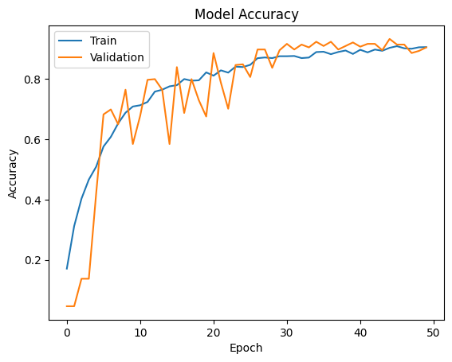

```python
plt.plot(history_8.history['accuracy'])
plt.plot(history_8.history['val_accuracy'])
plt.title('Model Accuracy')
plt.ylabel('Accuracy')
plt.xlabel('Epoch')
plt.legend(['Train', 'Validation'], loc='upper left')
plt.show()
```

```python
y_pred=model_8.predict(X_test_normalized)
```

```
15/15 ━━━━━━━━━━━━━━━━━━━━ 1s 47ms/step
```

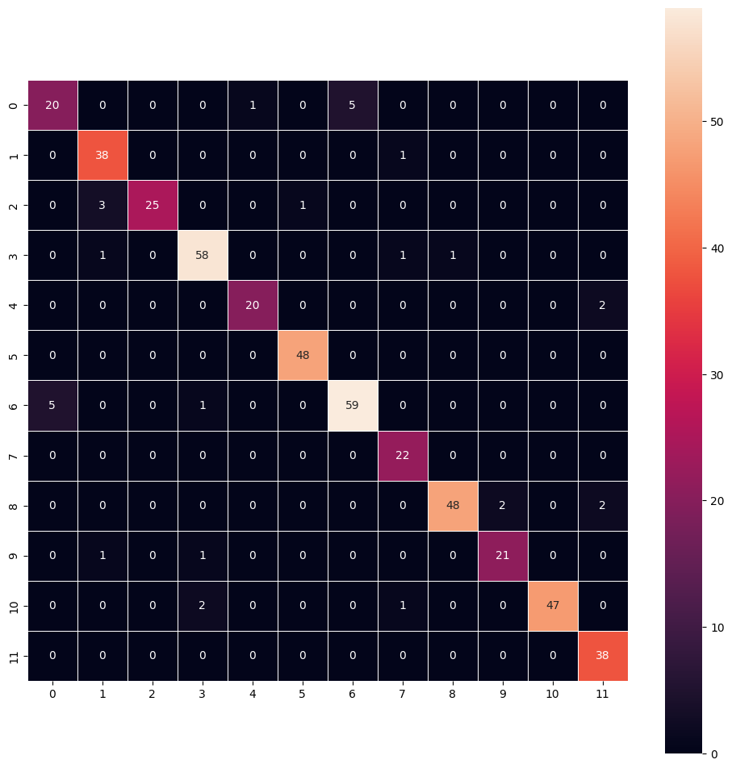

```python
y_pred_arg=np.argmax(y_pred,axis=1)
y_test_arg=np.argmax(y_test_encoded,axis=1)

confusion_matrix = tf.math.confusion_matrix(y_test_arg,y_pred_arg)
f, ax = plt.subplots(figsize=(12, 12))
sns.heatmap(
    confusion_matrix,
    annot=True,
    linewidths=.4,
    fmt="d",
    square=True,
    ax=ax
)
plt.show()
```

we need more aggressive augmentation

```python
backend.clear_session()

# Setting seeds for reproducibility
np.random.seed(1)
random.seed(1)
tf.random.set_seed(1)
```

```python
# More aggressive data augmentation
datagen = ImageDataGenerator(
    rotation_range=30,  # Increased
    width_shift_range=0.3,  # Increased
    height_shift_range=0.3,  # Increased
    shear_range=0.3,  # Increased
    zoom_range=0.3,  # Increased
    horizontal_flip=True,
    fill_mode='nearest'
)
```

```python
datagen.fit(X_train_normalized)
```

```python
#model 6 again but with aggressive augmentation seen above
model_9 = Sequential()

model_9.add(Conv2D(64, (1, 1), activation='relu', padding="same", input_shape=(64, 64, 3)))
model_9.add(BatchNormalization())
model_9.add(MaxPooling2D((2, 2), padding='same'))

model_9.add(Conv2D(128, (1, 1), activation='relu', padding="same"))
model_9.add(BatchNormalization())
model_9.add(MaxPooling2D((2, 2), padding='same'))

model_9.add(Conv2D(128, (1, 1), activation='relu', padding="same"))
model_9.add(BatchNormalization())
model_9.add(MaxPooling2D((2, 2), padding='same'))

model_9.add(Conv2D(128, (3, 3), activation='relu', padding="same"))
model_9.add(BatchNormalization())
model_9.add(MaxPooling2D((2, 2), padding='same'))

model_9.add(Conv2D(64, (3, 3), activation='relu', padding="same"))
model_9.add(BatchNormalization())
model_9.add(MaxPooling2D((2, 2), padding='same'))

model_9.add(Flatten())

# More neurons
model_9.add(Dense(128, activation='relu'))
model_9.add(BatchNormalization())
model_9.add(Dropout(0.5))

model_9.add(Dense(64, activation='relu'))
model_9.add(BatchNormalization())
model_9.add(Dropout(0.5))

model_9.add(Dense(12, activation='softmax'))

opt = Adam(learning_rate=0.0005)

model_9.compile(optimizer=opt, loss='categorical_crossentropy', metrics=['accuracy'])

model_9.summary()
```

```
Model: "sequential"
```

```
┏━━━━━━━━━━━━━━━━━━━━━━━━━━━━━━━━━━━━━━┳━━━━━━━━━━━━━━━━━━━━━━━━━━━━━┳━━━━━━━━━━━━━━━━━┓
┃ Layer (type)                         ┃ Output Shape                ┃         Param # ┃
┡━━━━━━━━━━━━━━━━━━━━━━━━━━━━━━━━━━━━━━╇━━━━━━━━━━━━━━━━━━━━━━━━━━━━━╇━━━━━━━━━━━━━━━━━┩
│ conv2d (Conv2D)                      │ (None, 64, 64, 64)          │             256 │
├──────────────────────────────────────┼─────────────────────────────┼─────────────────┤
│ batch_normalization                  │ (None, 64, 64, 64)          │             256 │
│ (BatchNormalization)                 │                             │                 │
├──────────────────────────────────────┼─────────────────────────────┼─────────────────┤
│ max_pooling2d (MaxPooling2D)         │ (None, 32, 32, 64)          │               0 │
├──────────────────────────────────────┼─────────────────────────────┼─────────────────┤
│ conv2d_1 (Conv2D)                    │ (None, 32, 32, 128)         │           8,320 │
├──────────────────────────────────────┼─────────────────────────────┼─────────────────┤
│ batch_normalization_1                │ (None, 32, 32, 128)         │             512 │
│ (BatchNormalization)                 │                             │                 │
├──────────────────────────────────────┼─────────────────────────────┼─────────────────┤
│ max_pooling2d_1 (MaxPooling2D)       │ (None, 16, 16, 128)         │               0 │
├──────────────────────────────────────┼─────────────────────────────┼─────────────────┤
│ conv2d_2 (Conv2D)                    │ (None, 16, 16, 128)         │          16,512 │
├──────────────────────────────────────┼─────────────────────────────┼─────────────────┤
│ batch_normalization_2                │ (None, 16, 16, 128)         │             512 │
│ (BatchNormalization)                 │                             │                 │
├──────────────────────────────────────┼─────────────────────────────┼─────────────────┤
│ max_pooling2d_2 (MaxPooling2D)       │ (None, 8, 8, 128)           │               0 │
├──────────────────────────────────────┼─────────────────────────────┼─────────────────┤
│ conv2d_3 (Conv2D)                    │ (None, 8, 8, 128)           │         147,584 │
├──────────────────────────────────────┼─────────────────────────────┼─────────────────┤
│ batch_normalization_3                │ (None, 8, 8, 128)           │             512 │
│ (BatchNormalization)                 │                             │                 │
├──────────────────────────────────────┼─────────────────────────────┼─────────────────┤
│ max_pooling2d_3 (MaxPooling2D)       │ (None, 4, 4, 128)           │               0 │
├──────────────────────────────────────┼─────────────────────────────┼─────────────────┤
│ conv2d_4 (Conv2D)                    │ (None, 4, 4, 64)            │          73,792 │
├──────────────────────────────────────┼─────────────────────────────┼─────────────────┤
│ batch_normalization_4                │ (None, 4, 4, 64)            │             256 │
│ (BatchNormalization)                 │                             │                 │
├──────────────────────────────────────┼─────────────────────────────┼─────────────────┤
│ max_pooling2d_4 (MaxPooling2D)       │ (None, 2, 2, 64)            │               0 │
├──────────────────────────────────────┼─────────────────────────────┼─────────────────┤
│ flatten (Flatten)                    │ (None, 256)                 │               0 │
├──────────────────────────────────────┼─────────────────────────────┼─────────────────┤
│ dense (Dense)                        │ (None, 128)                 │          32,896 │
├──────────────────────────────────────┼─────────────────────────────┼─────────────────┤
│ batch_normalization_5                │ (None, 128)                 │             512 │
│ (BatchNormalization)                 │                             │                 │
├──────────────────────────────────────┼─────────────────────────────┼─────────────────┤
│ dropout (Dropout)                    │ (None, 128)                 │               0 │
├──────────────────────────────────────┼─────────────────────────────┼─────────────────┤
│ dense_1 (Dense)                      │ (None, 64)                  │           8,256 │
├──────────────────────────────────────┼─────────────────────────────┼─────────────────┤
│ batch_normalization_6                │ (None, 64)                  │             256 │
│ (BatchNormalization)                 │                             │                 │
├──────────────────────────────────────┼─────────────────────────────┼─────────────────┤
│ dropout_1 (Dropout)                  │ (None, 64)                  │               0 │
├──────────────────────────────────────┼─────────────────────────────┼─────────────────┤
│ dense_2 (Dense)                      │ (None, 12)                  │             780 │
└──────────────────────────────────────┴─────────────────────────────┴─────────────────┘
```

```
 Total params: 291,212 (1.11 MB)
```

```
 Trainable params: 289,804 (1.11 MB)
```

```
 Non-trainable params: 1,408 (5.50 KB)
```

```python
history_9 = model_9.fit(
    datagen.flow(X_train_normalized, y_train_encoded, batch_size=32), #flow will augment the images on the fly
    epochs=50,
    validation_data=(X_val_normalized, y_val_encoded),
    verbose=2,
    callbacks=[reduced_lr]
)
```

```
121/121 - 24s - 197ms/step - accuracy: 0.1716 - loss: 2.9956 - val_accuracy: 0.1355 - val_loss: 2.6279 - learning_rate: 5.0000e-04
121/121 - 7s - 55ms/step - accuracy: 0.2826 - loss: 2.3206 - val_accuracy: 0.1379 - val_loss: 4.0979 - learning_rate: 5.0000e-04
121/121 - 11s - 89ms/step - accuracy: 0.3634 - loss: 1.9839 - val_accuracy: 0.1379 - val_loss: 3.8934 - learning_rate: 5.0000e-04
121/121 - 5s - 45ms/step - accuracy: 0.4011 - loss: 1.7978 - val_accuracy: 0.1402 - val_loss: 3.7150 - learning_rate: 5.0000e-04
121/121 - 7s - 55ms/step - accuracy: 0.4414 - loss: 1.6485 - val_accuracy: 0.2757 - val_loss: 2.7906 - learning_rate: 5.0000e-04
121/121 - 5s - 43ms/step - accuracy: 0.4994 - loss: 1.4935 - val_accuracy: 0.5280 - val_loss: 1.4035 - learning_rate: 5.0000e-04
121/121 - 6s - 53ms/step - accuracy: 0.5279 - loss: 1.4153 - val_accuracy: 0.6729 - val_loss: 0.9907 - learning_rate: 5.0000e-04
121/121 - 9s - 75ms/step - accuracy: 0.5636 - loss: 1.3014 - val_accuracy: 0.6589 - val_loss: 1.0223 - learning_rate: 5.0000e-04
121/121 - 7s - 55ms/step - accuracy: 0.6140 - loss: 1.1952 - val_accuracy: 0.6752 - val_loss: 0.9255 - learning_rate: 5.0000e-04
121/121 - 5s - 43ms/step - accuracy: 0.6496 - loss: 1.0776 - val_accuracy: 0.7827 - val_loss: 0.6647 - learning_rate: 5.0000e-04
121/121 - 8s - 64ms/step - accuracy: 0.6561 - loss: 1.0294 - val_accuracy: 0.5958 - val_loss: 1.1719 - learning_rate: 5.0000e-04
121/121 - 5s - 44ms/step - accuracy: 0.6618 - loss: 1.0218 - val_accuracy: 0.7056 - val_loss: 0.8043 - learning_rate: 5.0000e-04
121/121 - 6s - 51ms/step - accuracy: 0.6862 - loss: 0.9423 - val_accuracy: 0.7126 - val_loss: 0.8248 - learning_rate: 5.0000e-04
121/121 - 9s - 77ms/step - accuracy: 0.7125 - loss: 0.8634 - val_accuracy: 0.8411 - val_loss: 0.5224 - learning_rate: 5.0000e-04
121/121 - 7s - 54ms/step - accuracy: 0.7151 - loss: 0.8453 - val_accuracy: 0.7921 - val_loss: 0.5859 - learning_rate: 5.0000e-04
121/121 - 5s - 44ms/step - accuracy: 0.7284 - loss: 0.8093 - val_accuracy: 0.6729 - val_loss: 1.0664 - learning_rate: 5.0000e-04
121/121 - 10s - 85ms/step - accuracy: 0.7414 - loss: 0.7783 - val_accuracy: 0.7407 - val_loss: 0.7605 - learning_rate: 5.0000e-04
121/121 - 6s - 46ms/step - accuracy: 0.7510 - loss: 0.7481 - val_accuracy: 0.6075 - val_loss: 1.3066 - learning_rate: 5.0000e-04

Epoch 19: ReduceLROnPlateau reducing learning rate to 0.00010000000474974513.
121/121 - 6s - 52ms/step - accuracy: 0.7575 - loss: 0.7192 - val_accuracy: 0.8084 - val_loss: 0.5899 - learning_rate: 5.0000e-04
121/121 - 5s - 44ms/step - accuracy: 0.7842 - loss: 0.6423 - val_accuracy: 0.8575 - val_loss: 0.4554 - learning_rate: 1.0000e-04
121/121 - 7s - 55ms/step - accuracy: 0.7897 - loss: 0.6398 - val_accuracy: 0.8294 - val_loss: 0.5075 - learning_rate: 1.0000e-04
121/121 - 5s - 43ms/step - accuracy: 0.7913 - loss: 0.6348 - val_accuracy: 0.8248 - val_loss: 0.5234 - learning_rate: 1.0000e-04
121/121 - 7s - 54ms/step - accuracy: 0.8017 - loss: 0.6008 - val_accuracy: 0.7640 - val_loss: 0.6503 - learning_rate: 1.0000e-04
121/121 - 5s - 43ms/step - accuracy: 0.8139 - loss: 0.5786 - val_accuracy: 0.8832 - val_loss: 0.3768 - learning_rate: 1.0000e-04
121/121 - 6s - 46ms/step - accuracy: 0.8066 - loss: 0.5830 - val_accuracy: 0.8178 - val_loss: 0.5148 - learning_rate: 1.0000e-04
121/121 - 10s - 81ms/step - accuracy: 0.8037 - loss: 0.5922 - val_accuracy: 0.8808 - val_loss: 0.3778 - learning_rate: 1.0000e-04
121/121 - 7s - 54ms/step - accuracy: 0.8160 - loss: 0.5786 - val_accuracy: 0.8949 - val_loss: 0.3653 - learning_rate: 1.0000e-04
121/121 - 9s - 77ms/step - accuracy: 0.8128 - loss: 0.5818 - val_accuracy: 0.8505 - val_loss: 0.4520 - learning_rate: 1.0000e-04
121/121 - 6s - 51ms/step - accuracy: 0.8147 - loss: 0.5732 - val_accuracy: 0.8692 - val_loss: 0.4045 - learning_rate: 1.0000e-04
121/121 - 5s - 44ms/step - accuracy: 0.8082 - loss: 0.5579 - val_accuracy: 0.8832 - val_loss: 0.3761 - learning_rate: 1.0000e-04
121/121 - 7s - 55ms/step - accuracy: 0.8196 - loss: 0.5425 - val_accuracy: 0.8364 - val_loss: 0.4524 - learning_rate: 1.0000e-04

Epoch 32: ReduceLROnPlateau reducing learning rate to 2.0000000949949027e-05.
121/121 - 5s - 44ms/step - accuracy: 0.8204 - loss: 0.5450 - val_accuracy: 0.8832 - val_loss: 0.3873 - learning_rate: 1.0000e-04
121/121 - 7s - 55ms/step - accuracy: 0.8188 - loss: 0.5510 - val_accuracy: 0.8949 - val_loss: 0.3538 - learning_rate: 2.0000e-05
```

[output cut: 19 more lines]

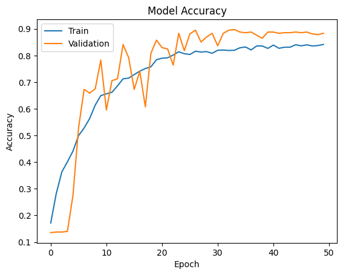

```python
plt.plot(history_9.history['accuracy'])
plt.plot(history_9.history['val_accuracy'])
plt.title('Model Accuracy')
plt.ylabel('Accuracy')
plt.xlabel('Epoch')
plt.legend(['Train', 'Validation'], loc='upper left')
plt.show()
```

```python
y_pred=model_9.predict(X_test_normalized)
```

```
15/15 ━━━━━━━━━━━━━━━━━━━━ 1s 50ms/step
```

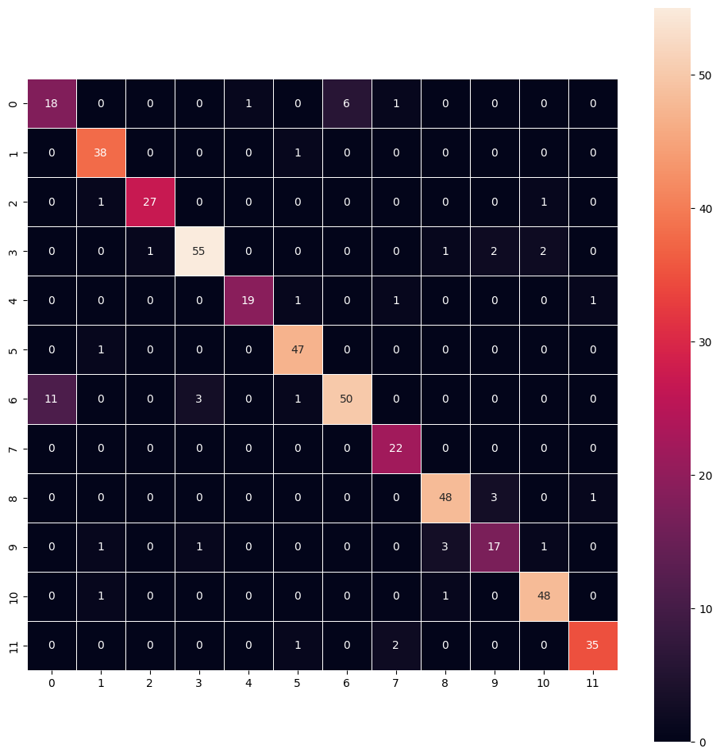

```python
y_pred_arg=np.argmax(y_pred,axis=1)
y_test_arg=np.argmax(y_test_encoded,axis=1)

confusion_matrix = tf.math.confusion_matrix(y_test_arg,y_pred_arg)
f, ax = plt.subplots(figsize=(12, 12))
sns.heatmap(
    confusion_matrix,
    annot=True,
    linewidths=.4,
    fmt="d",
    square=True,
    ax=ax
)
plt.show()
```

the problem is with the two blades of grass... after looking at the images again it appears that the grass outline is hard to see against the pebble background with that brightness hue and contrast... perhaps by randomly choosing the brightness and contrast we can augement enough of the grass so that our model is able to learn the difference whether that is like the bend or the thickness or length or something.

```python
backend.clear_session()

np.random.seed(1)
random.seed(1)
tf.random.set_seed(1)
```

```python
datagen = ImageDataGenerator(
    rotation_range=20,
    width_shift_range=0.2,
    height_shift_range=0.2,
    shear_range=0.2,
    horizontal_flip=True,
    fill_mode='nearest',
    brightness_range=[0.8, 1.2],  # a range
)
datagen.fit(X_train_normalized)
```

```python
reduced_lr = ReduceLROnPlateau(
    monitor='val_loss',  # telling it what to monitor
    factor=0.2,          # Factor by which the learning rate will be reduced
    patience=5,          # Number of epochs with no improvement after which learning rate will be reduced
    min_lr=1e-5,         # Lower bound on the learning rate
    verbose=1            # Print messages about learning rate changes
)
```

hue and contrast werent working... chat gpt said i had to just take it out... if this doesnt do good ill try transfer learning.

```python
model_10 = Sequential()

model_10.add(Conv2D(64, (1, 1), activation='relu', padding="same", input_shape=(64, 64, 3)))
model_10.add(BatchNormalization())
model_10.add(MaxPooling2D((2, 2), padding='same'))

model_10.add(Conv2D(128, (1, 1), activation='relu', padding="same"))
model_10.add(BatchNormalization())
model_10.add(MaxPooling2D((2, 2), padding='same'))

model_10.add(Conv2D(128, (1, 1), activation='relu', padding="same"))
model_10.add(BatchNormalization())
model_10.add(MaxPooling2D((2, 2), padding='same'))

model_10.add(Conv2D(128, (3, 3), activation='relu', padding="same"))
model_10.add(BatchNormalization())
model_10.add(MaxPooling2D((2, 2), padding='same'))

model_10.add(Conv2D(64, (3, 3), activation='relu', padding="same"))
model_10.add(BatchNormalization())
model_10.add(MaxPooling2D((2, 2), padding='same'))

model_10.add(Flatten())

model_10.add(Dense(128, activation='relu'))
model_10.add(BatchNormalization())
model_10.add(Dropout(0.5))

model_10.add(Dense(64, activation='relu'))
model_10.add(BatchNormalization())
model_10.add(Dropout(0.5))

model_10.add(Dense(12, activation='softmax'))

opt = Adam(learning_rate=0.0005)

model_10.compile(optimizer=opt, loss='categorical_crossentropy', metrics=['accuracy'])

model_10.summary()
```

```
Model: "sequential"
```

```
┏━━━━━━━━━━━━━━━━━━━━━━━━━━━━━━━━━━━━━━┳━━━━━━━━━━━━━━━━━━━━━━━━━━━━━┳━━━━━━━━━━━━━━━━━┓
┃ Layer (type)                         ┃ Output Shape                ┃         Param # ┃
┡━━━━━━━━━━━━━━━━━━━━━━━━━━━━━━━━━━━━━━╇━━━━━━━━━━━━━━━━━━━━━━━━━━━━━╇━━━━━━━━━━━━━━━━━┩
│ conv2d (Conv2D)                      │ (None, 64, 64, 64)          │             256 │
├──────────────────────────────────────┼─────────────────────────────┼─────────────────┤
│ batch_normalization                  │ (None, 64, 64, 64)          │             256 │
│ (BatchNormalization)                 │                             │                 │
├──────────────────────────────────────┼─────────────────────────────┼─────────────────┤
│ max_pooling2d (MaxPooling2D)         │ (None, 32, 32, 64)          │               0 │
├──────────────────────────────────────┼─────────────────────────────┼─────────────────┤
│ conv2d_1 (Conv2D)                    │ (None, 32, 32, 128)         │           8,320 │
├──────────────────────────────────────┼─────────────────────────────┼─────────────────┤
│ batch_normalization_1                │ (None, 32, 32, 128)         │             512 │
│ (BatchNormalization)                 │                             │                 │
├──────────────────────────────────────┼─────────────────────────────┼─────────────────┤
│ max_pooling2d_1 (MaxPooling2D)       │ (None, 16, 16, 128)         │               0 │
├──────────────────────────────────────┼─────────────────────────────┼─────────────────┤
│ conv2d_2 (Conv2D)                    │ (None, 16, 16, 128)         │          16,512 │
├──────────────────────────────────────┼─────────────────────────────┼─────────────────┤
│ batch_normalization_2                │ (None, 16, 16, 128)         │             512 │
│ (BatchNormalization)                 │                             │                 │
├──────────────────────────────────────┼─────────────────────────────┼─────────────────┤
│ max_pooling2d_2 (MaxPooling2D)       │ (None, 8, 8, 128)           │               0 │
├──────────────────────────────────────┼─────────────────────────────┼─────────────────┤
│ conv2d_3 (Conv2D)                    │ (None, 8, 8, 128)           │         147,584 │
├──────────────────────────────────────┼─────────────────────────────┼─────────────────┤
│ batch_normalization_3                │ (None, 8, 8, 128)           │             512 │
│ (BatchNormalization)                 │                             │                 │
├──────────────────────────────────────┼─────────────────────────────┼─────────────────┤
│ max_pooling2d_3 (MaxPooling2D)       │ (None, 4, 4, 128)           │               0 │
├──────────────────────────────────────┼─────────────────────────────┼─────────────────┤
│ conv2d_4 (Conv2D)                    │ (None, 4, 4, 64)            │          73,792 │
├──────────────────────────────────────┼─────────────────────────────┼─────────────────┤
│ batch_normalization_4                │ (None, 4, 4, 64)            │             256 │
│ (BatchNormalization)                 │                             │                 │
├──────────────────────────────────────┼─────────────────────────────┼─────────────────┤
│ max_pooling2d_4 (MaxPooling2D)       │ (None, 2, 2, 64)            │               0 │
├──────────────────────────────────────┼─────────────────────────────┼─────────────────┤
│ flatten (Flatten)                    │ (None, 256)                 │               0 │
├──────────────────────────────────────┼─────────────────────────────┼─────────────────┤
│ dense (Dense)                        │ (None, 128)                 │          32,896 │
├──────────────────────────────────────┼─────────────────────────────┼─────────────────┤
│ batch_normalization_5                │ (None, 128)                 │             512 │
│ (BatchNormalization)                 │                             │                 │
├──────────────────────────────────────┼─────────────────────────────┼─────────────────┤
│ dropout (Dropout)                    │ (None, 128)                 │               0 │
├──────────────────────────────────────┼─────────────────────────────┼─────────────────┤
│ dense_1 (Dense)                      │ (None, 64)                  │           8,256 │
├──────────────────────────────────────┼─────────────────────────────┼─────────────────┤
│ batch_normalization_6                │ (None, 64)                  │             256 │
│ (BatchNormalization)                 │                             │                 │
├──────────────────────────────────────┼─────────────────────────────┼─────────────────┤
│ dropout_1 (Dropout)                  │ (None, 64)                  │               0 │
├──────────────────────────────────────┼─────────────────────────────┼─────────────────┤
│ dense_2 (Dense)                      │ (None, 12)                  │             780 │
└──────────────────────────────────────┴─────────────────────────────┴─────────────────┘
```

```
 Total params: 291,212 (1.11 MB)
```

```
 Trainable params: 289,804 (1.11 MB)
```

```
 Non-trainable params: 1,408 (5.50 KB)
```

```python
history_10 = model_10.fit(
    datagen.flow(X_train_normalized, y_train_encoded, batch_size=32),  # flow will augment the images on the fly
    epochs=50,
    validation_data=(X_val_normalized, y_val_encoded),
    verbose=2,
    callbacks=[reduced_lr]
)
```

```
121/121 - 27s - 220ms/step - accuracy: 0.1276 - loss: 2.4657 - val_accuracy: 0.0491 - val_loss: 3.8993 - learning_rate: 5.0000e-04
121/121 - 27s - 220ms/step - accuracy: 0.1321 - loss: 2.4321 - val_accuracy: 0.0491 - val_loss: 255.5227 - learning_rate: 5.0000e-04
121/121 - 6s - 51ms/step - accuracy: 0.1326 - loss: 2.4552 - val_accuracy: 0.0491 - val_loss: 99998.7812 - learning_rate: 5.0000e-04
121/121 - 8s - 68ms/step - accuracy: 0.1321 - loss: 2.4341 - val_accuracy: 0.0514 - val_loss: 534048.7500 - learning_rate: 5.0000e-04
121/121 - 6s - 52ms/step - accuracy: 0.1385 - loss: 2.4344 - val_accuracy: 0.0467 - val_loss: 4326140.0000 - learning_rate: 5.0000e-04

Epoch 6: ReduceLROnPlateau reducing learning rate to 0.00010000000474974513.
121/121 - 8s - 62ms/step - accuracy: 0.1372 - loss: 2.4317 - val_accuracy: 0.0654 - val_loss: 13120556.0000 - learning_rate: 5.0000e-04
121/121 - 6s - 51ms/step - accuracy: 0.1341 - loss: 2.4303 - val_accuracy: 0.0467 - val_loss: 25829356.0000 - learning_rate: 1.0000e-04
121/121 - 8s - 62ms/step - accuracy: 0.1370 - loss: 2.4375 - val_accuracy: 0.0491 - val_loss: 2555666.7500 - learning_rate: 1.0000e-04
121/121 - 6s - 51ms/step - accuracy: 0.1310 - loss: 2.4371 - val_accuracy: 0.0561 - val_loss: 3716146.2500 - learning_rate: 1.0000e-04
121/121 - 8s - 63ms/step - accuracy: 0.1404 - loss: 2.4187 - val_accuracy: 0.1005 - val_loss: 3677371.2500 - learning_rate: 1.0000e-04

Epoch 11: ReduceLROnPlateau reducing learning rate to 2.0000000949949027e-05.
121/121 - 6s - 52ms/step - accuracy: 0.1471 - loss: 2.4318 - val_accuracy: 0.1332 - val_loss: 2438076.0000 - learning_rate: 1.0000e-04
121/121 - 7s - 61ms/step - accuracy: 0.1391 - loss: 2.4288 - val_accuracy: 0.1355 - val_loss: 915449.1250 - learning_rate: 2.0000e-05
121/121 - 6s - 51ms/step - accuracy: 0.1282 - loss: 2.4253 - val_accuracy: 0.1355 - val_loss: 1997377.2500 - learning_rate: 2.0000e-05
121/121 - 8s - 62ms/step - accuracy: 0.1300 - loss: 2.4353 - val_accuracy: 0.1051 - val_loss: 2719676.7500 - learning_rate: 2.0000e-05
121/121 - 6s - 52ms/step - accuracy: 0.1336 - loss: 2.4241 - val_accuracy: 0.1005 - val_loss: 9108051.0000 - learning_rate: 2.0000e-05

Epoch 16: ReduceLROnPlateau reducing learning rate to 1e-05.
121/121 - 7s - 61ms/step - accuracy: 0.1391 - loss: 2.4376 - val_accuracy: 0.0841 - val_loss: 1164757.6250 - learning_rate: 2.0000e-05
121/121 - 6s - 52ms/step - accuracy: 0.1326 - loss: 2.4253 - val_accuracy: 0.0514 - val_loss: 3455541.2500 - learning_rate: 1.0000e-05
121/121 - 8s - 63ms/step - accuracy: 0.1375 - loss: 2.4268 - val_accuracy: 0.1192 - val_loss: 3781589.7500 - learning_rate: 1.0000e-05
121/121 - 6s - 52ms/step - accuracy: 0.1365 - loss: 2.4282 - val_accuracy: 0.1028 - val_loss: 1562722.2500 - learning_rate: 1.0000e-05
121/121 - 8s - 62ms/step - accuracy: 0.1347 - loss: 2.4171 - val_accuracy: 0.1028 - val_loss: 14289766.0000 - learning_rate: 1.0000e-05
121/121 - 6s - 51ms/step - accuracy: 0.1352 - loss: 2.4466 - val_accuracy: 0.0888 - val_loss: 712724.2500 - learning_rate: 1.0000e-05
121/121 - 8s - 63ms/step - accuracy: 0.1424 - loss: 2.4189 - val_accuracy: 0.0631 - val_loss: 7421958.0000 - learning_rate: 1.0000e-05
121/121 - 6s - 52ms/step - accuracy: 0.1323 - loss: 2.4272 - val_accuracy: 0.0724 - val_loss: 3256720.5000 - learning_rate: 1.0000e-05
121/121 - 8s - 62ms/step - accuracy: 0.1375 - loss: 2.4396 - val_accuracy: 0.0537 - val_loss: 1369701.3750 - learning_rate: 1.0000e-05
121/121 - 6s - 51ms/step - accuracy: 0.1292 - loss: 2.4305 - val_accuracy: 0.0514 - val_loss: 3711536.7500 - learning_rate: 1.0000e-05
121/121 - 7s - 62ms/step - accuracy: 0.1269 - loss: 2.4247 - val_accuracy: 0.0467 - val_loss: 12815512.0000 - learning_rate: 1.0000e-05
121/121 - 6s - 53ms/step - accuracy: 0.1357 - loss: 2.4283 - val_accuracy: 0.1355 - val_loss: 3982571.7500 - learning_rate: 1.0000e-05
121/121 - 10s - 83ms/step - accuracy: 0.1349 - loss: 2.4251 - val_accuracy: 0.1379 - val_loss: 8093446.0000 - learning_rate: 1.0000e-05
121/121 - 7s - 62ms/step - accuracy: 0.1380 - loss: 2.4201 - val_accuracy: 0.0678 - val_loss: 84984880.0000 - learning_rate: 1.0000e-05
121/121 - 6s - 52ms/step - accuracy: 0.1378 - loss: 2.4356 - val_accuracy: 0.0584 - val_loss: 2390859.0000 - learning_rate: 1.0000e-05
121/121 - 8s - 63ms/step - accuracy: 0.1349 - loss: 2.4247 - val_accuracy: 0.0607 - val_loss: 5810914.5000 - learning_rate: 1.0000e-05
```

[output cut: 19 more lines]

```python
y_pred = model_10.predict(X_test_normalized)
```

```
15/15 ━━━━━━━━━━━━━━━━━━━━ 2s 77ms/step
```

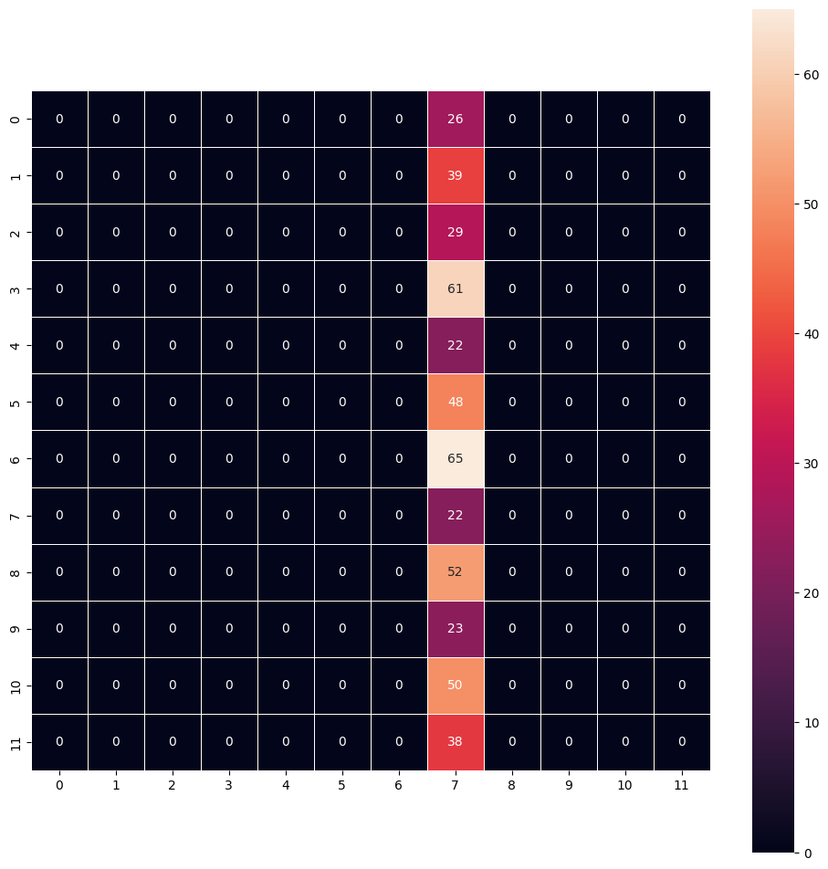

```python
y_pred_arg=np.argmax(y_pred,axis=1)
y_test_arg=np.argmax(y_test_encoded,axis=1)

confusion_matrix = tf.math.confusion_matrix(y_test_arg,y_pred_arg)
f, ax = plt.subplots(figsize=(12, 12))
sns.heatmap(
    confusion_matrix,
    annot=True,
    linewidths=.4,
    fmt="d",
    square=True,
    ax=ax
)
plt.show()
```

no idea what went wrong here probably too wide a range of brightness not centered around the inds found in the images

now we need to try some transfer learning

```python
backend.clear_session()

np.random.seed(1)
random.seed(1)
tf.random.set_seed(1)
```

```python
datagen = ImageDataGenerator(
    rotation_range=20,
    width_shift_range=0.2,
    height_shift_range=0.2,
    shear_range=0.2,
    horizontal_flip=True,
    fill_mode='nearest'
)
```

```python
from tensorflow.keras.models import Model
from keras.applications.vgg16 import VGG16

vgg_model = VGG16(weights='imagenet', include_top = False, input_shape = (64,64,3))
vgg_model.summary()
```

```
Model: "vgg16"
```

```
┏━━━━━━━━━━━━━━━━━━━━━━━━━━━━━━━━━━━━━━┳━━━━━━━━━━━━━━━━━━━━━━━━━━━━━┳━━━━━━━━━━━━━━━━━┓
┃ Layer (type)                         ┃ Output Shape                ┃         Param # ┃
┡━━━━━━━━━━━━━━━━━━━━━━━━━━━━━━━━━━━━━━╇━━━━━━━━━━━━━━━━━━━━━━━━━━━━━╇━━━━━━━━━━━━━━━━━┩
│ input_layer (InputLayer)             │ (None, 64, 64, 3)           │               0 │
├──────────────────────────────────────┼─────────────────────────────┼─────────────────┤
│ block1_conv1 (Conv2D)                │ (None, 64, 64, 64)          │           1,792 │
├──────────────────────────────────────┼─────────────────────────────┼─────────────────┤
│ block1_conv2 (Conv2D)                │ (None, 64, 64, 64)          │          36,928 │
├──────────────────────────────────────┼─────────────────────────────┼─────────────────┤
│ block1_pool (MaxPooling2D)           │ (None, 32, 32, 64)          │               0 │
├──────────────────────────────────────┼─────────────────────────────┼─────────────────┤
│ block2_conv1 (Conv2D)                │ (None, 32, 32, 128)         │          73,856 │
├──────────────────────────────────────┼─────────────────────────────┼─────────────────┤
│ block2_conv2 (Conv2D)                │ (None, 32, 32, 128)         │         147,584 │
├──────────────────────────────────────┼─────────────────────────────┼─────────────────┤
│ block2_pool (MaxPooling2D)           │ (None, 16, 16, 128)         │               0 │
├──────────────────────────────────────┼─────────────────────────────┼─────────────────┤
│ block3_conv1 (Conv2D)                │ (None, 16, 16, 256)         │         295,168 │
├──────────────────────────────────────┼─────────────────────────────┼─────────────────┤
│ block3_conv2 (Conv2D)                │ (None, 16, 16, 256)         │         590,080 │
├──────────────────────────────────────┼─────────────────────────────┼─────────────────┤
│ block3_conv3 (Conv2D)                │ (None, 16, 16, 256)         │         590,080 │
├──────────────────────────────────────┼─────────────────────────────┼─────────────────┤
│ block3_pool (MaxPooling2D)           │ (None, 8, 8, 256)           │               0 │
├──────────────────────────────────────┼─────────────────────────────┼─────────────────┤
│ block4_conv1 (Conv2D)                │ (None, 8, 8, 512)           │       1,180,160 │
├──────────────────────────────────────┼─────────────────────────────┼─────────────────┤
│ block4_conv2 (Conv2D)                │ (None, 8, 8, 512)           │       2,359,808 │
├──────────────────────────────────────┼─────────────────────────────┼─────────────────┤
│ block4_conv3 (Conv2D)                │ (None, 8, 8, 512)           │       2,359,808 │
├──────────────────────────────────────┼─────────────────────────────┼─────────────────┤
│ block4_pool (MaxPooling2D)           │ (None, 4, 4, 512)           │               0 │
├──────────────────────────────────────┼─────────────────────────────┼─────────────────┤
│ block5_conv1 (Conv2D)                │ (None, 4, 4, 512)           │       2,359,808 │
├──────────────────────────────────────┼─────────────────────────────┼─────────────────┤
│ block5_conv2 (Conv2D)                │ (None, 4, 4, 512)           │       2,359,808 │
├──────────────────────────────────────┼─────────────────────────────┼─────────────────┤
│ block5_conv3 (Conv2D)                │ (None, 4, 4, 512)           │       2,359,808 │
├──────────────────────────────────────┼─────────────────────────────┼─────────────────┤
│ block5_pool (MaxPooling2D)           │ (None, 2, 2, 512)           │               0 │
└──────────────────────────────────────┴─────────────────────────────┴─────────────────┘
```

```
 Total params: 14,714,688 (56.13 MB)
```

```
 Trainable params: 14,714,688 (56.13 MB)
```

```
 Non-trainable params: 0 (0.00 B)
```

```python
# Making all the layers of the VGG model non-trainable.
for layer in vgg_model.layers:
    layer.trainable = False
```

```python
model_11 = Sequential()

# Adding the convolutional part of the VGG16 model in place of ours
model_11.add(vgg_model)

# Flattening the output of the VGG16 model so we can add dense layers
model_11.add(Flatten())

model_11.add(Dense(128, activation='relu'))
model_11.add(BatchNormalization())
model_11.add(Dropout(0.2))
model_11.add(Dense(64, activation='relu'))
model_11.add(BatchNormalization())
model_11.add(Dense(12, activation='softmax'))
opt=Adam()

model_11.compile(optimizer=opt, loss='categorical_crossentropy', metrics=['accuracy'])

model_11.summary()
```

```
Model: "sequential_1"
```

```
┏━━━━━━━━━━━━━━━━━━━━━━━━━━━━━━━━━━━━━━┳━━━━━━━━━━━━━━━━━━━━━━━━━━━━━┳━━━━━━━━━━━━━━━━━┓
┃ Layer (type)                         ┃ Output Shape                ┃         Param # ┃
┡━━━━━━━━━━━━━━━━━━━━━━━━━━━━━━━━━━━━━━╇━━━━━━━━━━━━━━━━━━━━━━━━━━━━━╇━━━━━━━━━━━━━━━━━┩
│ vgg16 (Functional)                   │ (None, 2, 2, 512)           │      14,714,688 │
├──────────────────────────────────────┼─────────────────────────────┼─────────────────┤
│ flatten_1 (Flatten)                  │ (None, 2048)                │               0 │
├──────────────────────────────────────┼─────────────────────────────┼─────────────────┤
│ dense_3 (Dense)                      │ (None, 128)                 │         262,272 │
├──────────────────────────────────────┼─────────────────────────────┼─────────────────┤
│ batch_normalization                  │ (None, 128)                 │             512 │
│ (BatchNormalization)                 │                             │                 │
├──────────────────────────────────────┼─────────────────────────────┼─────────────────┤
│ dropout_1 (Dropout)                  │ (None, 128)                 │               0 │
├──────────────────────────────────────┼─────────────────────────────┼─────────────────┤
│ dense_4 (Dense)                      │ (None, 64)                  │           8,256 │
├──────────────────────────────────────┼─────────────────────────────┼─────────────────┤
│ batch_normalization_1                │ (None, 64)                  │             256 │
│ (BatchNormalization)                 │                             │                 │
├──────────────────────────────────────┼─────────────────────────────┼─────────────────┤
│ dense_5 (Dense)                      │ (None, 12)                  │             780 │
└──────────────────────────────────────┴─────────────────────────────┴─────────────────┘
```

```
 Total params: 14,986,764 (57.17 MB)
```

```
 Trainable params: 271,692 (1.04 MB)
```

```
 Non-trainable params: 14,715,072 (56.13 MB)
```

```python
batch_size=32

history_11 = model_11.fit(datagen.flow(X_train_normalized,y_train_encoded,
                                       batch_size=32,
                                       seed=42,
                                       shuffle=False),
                    epochs=50,
                    steps_per_epoch=X_train_normalized.shape[0] // batch_size,
                    validation_data=(X_val_normalized,y_val_encoded),
                    verbose=1)
```

[output not shown]

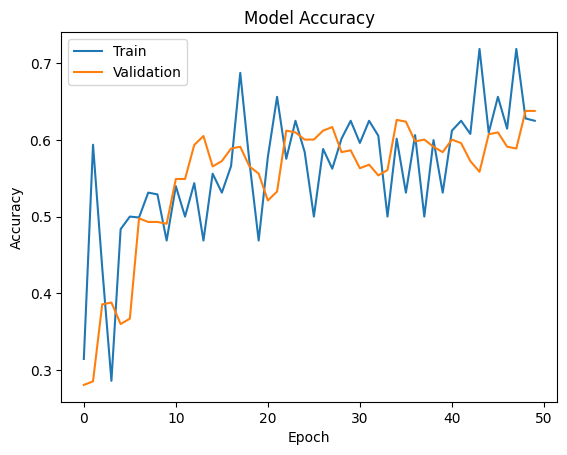

```python
plt.plot(history_11.history['accuracy'])
plt.plot(history_11.history['val_accuracy'])
plt.title('Model Accuracy')
plt.ylabel('Accuracy')
plt.xlabel('Epoch')
plt.legend(['Train', 'Validation'], loc='upper left')
plt.show()
```

```python
y_pred = model_11.predict(X_test_normalized)
```

```
15/15 ━━━━━━━━━━━━━━━━━━━━ 3s 160ms/step
```

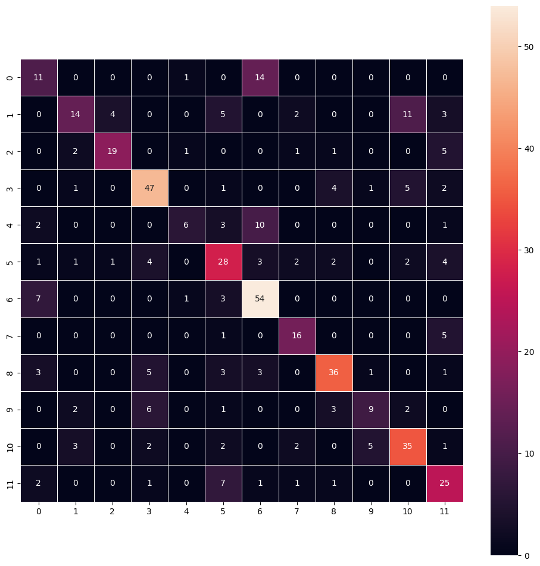

```python
y_pred_arg=np.argmax(y_pred,axis=1)
y_test_arg=np.argmax(y_test_encoded,axis=1)

confusion_matrix = tf.math.confusion_matrix(y_test_arg,y_pred_arg)
f, ax = plt.subplots(figsize=(12, 12))
sns.heatmap(
    confusion_matrix,
    annot=True,
    linewidths=.4,
    fmt="d",
    square=True,
    ax=ax
)
plt.show()
```

much worse

## Final Model

Comment on the final model you have selected and use the same in the below code to visualize the image.

```python
# Instantiate the ReduceLROnPlateau callback:
reduced_lr = ReduceLROnPlateau(
    monitor='val_loss',  # telling it what to monitor
    factor=0.2,          # Factor by which the learning rate will be reduced
    patience=5,          # Number of epochs with no improvement after which learning rate will be reduced
    min_lr=1e-5,         # Lower bound on the learning rate
    verbose=1            # Print messages about learning rate changes
)
```

```python
datagen = ImageDataGenerator(
    rotation_range=20,
    width_shift_range=0.2,
    height_shift_range=0.2,
    shear_range=0.2,
    zoom_range=0.2,
    horizontal_flip=True,
    fill_mode='nearest'
)

datagen.fit(X_train_normalized)
```

```python
#copy and paste of model 6
model = Sequential()

# Adding more tiny CNN layer filters
model.add(Conv2D(64, (1, 1), activation='relu', padding="same", input_shape=(64, 64, 3)))
model.add(BatchNormalization())  # Added Batch Normalization
model.add(MaxPooling2D((2, 2), padding='same'))

# More filters
model.add(Conv2D(128, (1, 1), activation='relu', padding="same"))  # Increased filters
model.add(BatchNormalization())  # Added Batch Normalization
model.add(MaxPooling2D((2, 2), padding='same'))

# More filters
model.add(Conv2D(128, (1, 1), activation='relu', padding="same"))  # Increased filters
model.add(BatchNormalization())  # Added Batch Normalization
model.add(MaxPooling2D((2, 2), padding='same'))

# Larger kernel size
model.add(Conv2D(128, (3, 3), activation='relu', padding="same"))  # Increased filters
model.add(BatchNormalization())  # Added Batch Normalization
model.add(MaxPooling2D((2, 2), padding='same'))

model.add(Conv2D(64, (3, 3), activation='relu', padding="same"))  # Increased filters
model.add(BatchNormalization())  # Added Batch Normalization
model.add(MaxPooling2D((2, 2), padding='same'))

model.add(Flatten())

# More neurons
model.add(Dense(128, activation='relu'))  # Increased neurons
model.add(BatchNormalization())  # Added Batch Normalization
model.add(Dropout(0.5))  # Increased Dropout

model.add(Dense(64, activation='relu'))  # Increased neurons, added layer
model.add(BatchNormalization())  # Added Batch Normalization
model.add(Dropout(0.5))  # Increased Dropout

model.add(Dense(12, activation='softmax'))

# Reduced the learning rate slightly
opt = Adam(learning_rate=0.0005)

model.compile(optimizer=opt, loss='categorical_crossentropy', metrics=['accuracy'])

# Model Summary
model.summary()
```

```
Model: "sequential_2"
```

```
┏━━━━━━━━━━━━━━━━━━━━━━━━━━━━━━━━━━━━━━┳━━━━━━━━━━━━━━━━━━━━━━━━━━━━━┳━━━━━━━━━━━━━━━━━┓
┃ Layer (type)                         ┃ Output Shape                ┃         Param # ┃
┡━━━━━━━━━━━━━━━━━━━━━━━━━━━━━━━━━━━━━━╇━━━━━━━━━━━━━━━━━━━━━━━━━━━━━╇━━━━━━━━━━━━━━━━━┩
│ conv2d (Conv2D)                      │ (None, 64, 64, 64)          │             256 │
├──────────────────────────────────────┼─────────────────────────────┼─────────────────┤
│ batch_normalization_2                │ (None, 64, 64, 64)          │             256 │
│ (BatchNormalization)                 │                             │                 │
├──────────────────────────────────────┼─────────────────────────────┼─────────────────┤
│ max_pooling2d (MaxPooling2D)         │ (None, 32, 32, 64)          │               0 │
├──────────────────────────────────────┼─────────────────────────────┼─────────────────┤
│ conv2d_1 (Conv2D)                    │ (None, 32, 32, 128)         │           8,320 │
├──────────────────────────────────────┼─────────────────────────────┼─────────────────┤
│ batch_normalization_3                │ (None, 32, 32, 128)         │             512 │
│ (BatchNormalization)                 │                             │                 │
├──────────────────────────────────────┼─────────────────────────────┼─────────────────┤
│ max_pooling2d_1 (MaxPooling2D)       │ (None, 16, 16, 128)         │               0 │
├──────────────────────────────────────┼─────────────────────────────┼─────────────────┤
│ conv2d_2 (Conv2D)                    │ (None, 16, 16, 128)         │          16,512 │
├──────────────────────────────────────┼─────────────────────────────┼─────────────────┤
│ batch_normalization_4                │ (None, 16, 16, 128)         │             512 │
│ (BatchNormalization)                 │                             │                 │
├──────────────────────────────────────┼─────────────────────────────┼─────────────────┤
│ max_pooling2d_2 (MaxPooling2D)       │ (None, 8, 8, 128)           │               0 │
├──────────────────────────────────────┼─────────────────────────────┼─────────────────┤
│ conv2d_3 (Conv2D)                    │ (None, 8, 8, 128)           │         147,584 │
├──────────────────────────────────────┼─────────────────────────────┼─────────────────┤
│ batch_normalization_5                │ (None, 8, 8, 128)           │             512 │
│ (BatchNormalization)                 │                             │                 │
├──────────────────────────────────────┼─────────────────────────────┼─────────────────┤
│ max_pooling2d_3 (MaxPooling2D)       │ (None, 4, 4, 128)           │               0 │
├──────────────────────────────────────┼─────────────────────────────┼─────────────────┤
│ conv2d_4 (Conv2D)                    │ (None, 4, 4, 64)            │          73,792 │
├──────────────────────────────────────┼─────────────────────────────┼─────────────────┤
│ batch_normalization_6                │ (None, 4, 4, 64)            │             256 │
│ (BatchNormalization)                 │                             │                 │
├──────────────────────────────────────┼─────────────────────────────┼─────────────────┤
│ max_pooling2d_4 (MaxPooling2D)       │ (None, 2, 2, 64)            │               0 │
├──────────────────────────────────────┼─────────────────────────────┼─────────────────┤
│ flatten_2 (Flatten)                  │ (None, 256)                 │               0 │
├──────────────────────────────────────┼─────────────────────────────┼─────────────────┤
│ dense_6 (Dense)                      │ (None, 128)                 │          32,896 │
├──────────────────────────────────────┼─────────────────────────────┼─────────────────┤
│ batch_normalization_7                │ (None, 128)                 │             512 │
│ (BatchNormalization)                 │                             │                 │
├──────────────────────────────────────┼─────────────────────────────┼─────────────────┤
│ dropout_2 (Dropout)                  │ (None, 128)                 │               0 │
├──────────────────────────────────────┼─────────────────────────────┼─────────────────┤
│ dense_7 (Dense)                      │ (None, 64)                  │           8,256 │
├──────────────────────────────────────┼─────────────────────────────┼─────────────────┤
│ batch_normalization_8                │ (None, 64)                  │             256 │
│ (BatchNormalization)                 │                             │                 │
├──────────────────────────────────────┼─────────────────────────────┼─────────────────┤
│ dropout_3 (Dropout)                  │ (None, 64)                  │               0 │
├──────────────────────────────────────┼─────────────────────────────┼─────────────────┤
│ dense_8 (Dense)                      │ (None, 12)                  │             780 │
└──────────────────────────────────────┴─────────────────────────────┴─────────────────┘
```

```
 Total params: 291,212 (1.11 MB)
```

```
 Trainable params: 289,804 (1.11 MB)
```

```
 Non-trainable params: 1,408 (5.50 KB)
```